# Module 78

#### Hemi-module gene counts:

543 probesets in hemi-module A.  
72 probesets in hemi-module B.  
Note: While the mapping of probesets to genes is usually one-to-one, some genes are targeted by multiple probesets, some probesets target multiple genes, and some probesets do not target any genes (i.e., the region of the genome they match is no longer considered genic).

#### Contrast SVE:

Signed variance explained (SVE) provides an indication of how similar a set of fold changes are to a gene module’s weight vector. An SVE value of 0.3, for example, indicates that 30% of the variance explained by the entire module set is accounted for by the module in question. Shown here are the SVE values for this module across a compendium of fold changes (contrasts). Extreme SVE values (e.g., > 0.05) indicate that those contrasts specifically induce (orange dots) or specifically repress (blue dots) this module. Examining the experimental conditions being compared in such contrasts (see tables below the figure) may provide insight into the gene module’s function.

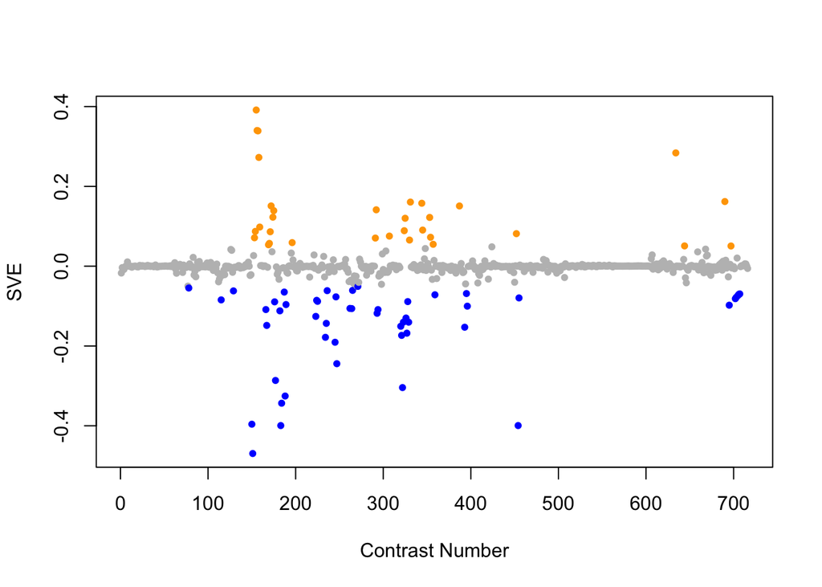

Positive SVE Contrasts:

|  | Contrast.Num | SVE | GEO.GSE | Cond.1 | Cond.2 | Mutation |
| --- | --- | --- | --- | --- | --- | --- |
| GSE47778.s1t1.vs.s2t1 | 155 | 0.39 | GSE47778 | N2; replicate 1 | daf-2; replicate 1 | daf-2 |
| GSE47778.s5t1.vs.s2t1 | 156 | 0.34 | GSE47778 | xpa-1 0mJ/cm2; replicate 1 | daf-2; replicate 1 | xpa-1 vs. daf-2 |
| GSE47778.s1t1.vs.s4t1 | 157 | 0.34 | GSE47778 | N2; replicate 1 | daf-2;daf-16; replicate 1 | daf-2;daf-16 |
| GSE19138.s1t1.vs.s0t1 | 634 | 0.28 | GSE19138 | ALG-1(-) 1 | WT1 | alg-1 |
| GSE47778.s5t1.vs.s4t1 | 158 | 0.27 | GSE47778 | xpa-1 0mJ/cm2; replicate 1 | daf-2;daf-16; replicate 1 | xpa-1 vs. daf-2;daf-16 |
| GSE11055.s1t6.vs.s2t6 | 690 | 0.16 | GSE11055 | L1 larvae 12 hr after hatching in the presence of food | L1 larvae 12 hr after hatching in the absence of food |  |
| GSE38997.s4t4.vs.s3t4 | 331 | 0.16 | GSE38997 | experiment 1 UVC-exposed samples at 51 h 1u51 | experiment 1 UVC- and EtBr-exposed samples at 51 h 1eu51 |  |
| GSE38997.s1t3.vs.s1t1 | 344 | 0.16 | GSE38997 | experiment 1 control samples at 48 h 1c48 | experiment 4 control samples at 3 h 4c3 |  |
| GSE47778.s5t3.vs.s2t3 | 172 | 0.15 | GSE47778 | xpa-1 10mJ/cm2; replicate 1 | daf-2; UV; replicate 1 | xpa-1 vs. daf-2 |
| GSE34026.s1t1.vs.s0t1 | 387 | 0.15 | GSE34026 | N2 exposed to hemolysin mutant of E7946, biological rep1 | N2 exposed to OP50(E.coli), biological rep1 |  |
| GSE41366C.s1t2.vs.s0t2 | 292 | 0.14 | GSE41366 | low_DDVP-continuous_expose-8h_harvest-rep1 | control-continuous_expose-2h_harvest-rep1 |  |
| GSE47778.s5t3.vs.s1t3 | 175 | 0.14 | GSE47778 | xpa-1 10mJ/cm2; replicate 1 | N2; UV; replicate 1 | xpa-1 |
| GSE47778.s5t3.vs.s4t3 | 174 | 0.12 | GSE47778 | xpa-1 10mJ/cm2; replicate 1 | daf-2;daf-16; UV; replicate 1 | xpa-1 vs. daf-2;daf-16 |
| GSE38997.s4t3.vs.s4t1 | 353 | 0.12 | GSE38997 | experiment 1 UVC-exposed samples at 48 h 1u48 | experiment 4 UVC-exposed samples at 3 h 4u3 |  |
| GSE38997.s4t3.vs.s3t3 | 325 | 0.12 | GSE38997 | experiment 1 UVC-exposed samples at 48 h 1u48 | experiment 1 UVC- and EtBr-exposed samples at 48 h 1eu48 |  |
| GSE47778.s5t1.vs.s1t1 | 159 | 0.10 | GSE47778 | xpa-1 0mJ/cm2; replicate 1 | N2; replicate 1 | xpa-1 |
| GSE38997.s1t4.vs.s1t1 | 345 | 0.09 | GSE38997 | experiment 1 control samples at 51 h 1c51 | experiment 4 control samples at 3 h 4c3 |  |
| GSE38997.s4t3.vs.s2t3 | 324 | 0.09 | GSE38997 | experiment 1 UVC-exposed samples at 48 h 1u48 | experiment 1 EtBr-exposed samples at 48 h 1e48 |  |
| GSE47778.s4t1.vs.s2t1 | 154 | 0.09 | GSE47778 | daf-2;daf-16; replicate 1 | daf-2; replicate 1 | daf-2;daf-16 vs. daf-2 |
| GSE47778.s1t3.vs.s2t3 | 171 | 0.09 | GSE47778 | N2; UV; replicate 1 | daf-2; UV; replicate 1 | daf-2 |
| GSE25633.s1t1.vs.s2t1 | 452 | 0.08 | GSE25633 | WT#1 | daf-19,daf-12#1 | daf-19;daf-12 |
| GSE41366C.s1t2.vs.s1t1 | 307 | 0.08 | GSE41366 | low_DDVP-continuous_expose-8h_harvest-rep1 | low_DDVP-continuous_expose-2h_harvest-rep1 |  |
| GSE38997.s4t4.vs.s4t1 | 354 | 0.07 | GSE38997 | experiment 1 UVC-exposed samples at 51 h 1u51 | experiment 4 UVC-exposed samples at 3 h 4u3 |  |
| GSE47778.s5t1.vs.s3t1 | 153 | 0.07 | GSE47778 | xpa-1 0mJ/cm2; replicate 1 | daf-16; replicate 1 | xpa-1 vs. daf-16 |
| GSE41366C.s2t2.vs.s0t2 | 291 | 0.07 | GSE41366 | high_DDVP-continuous_expose-8h_harvest-rep1 | control-continuous_expose-2h_harvest-rep1 |  |
| GSE38997.s4t4.vs.s2t4 | 330 | 0.07 | GSE38997 | experiment 1 UVC-exposed samples at 51 h 1u51 | experiment 1 EtBr-exposed samples at 51 h 1e51 |  |
| GSE43959.s1t1.vs.s3t1 | 196 | 0.06 | GSE43959 | N2 young adult on E. coli OP50 rep 1 | N2 young adult on Comamonas DA1877 rep 1 |  |
| GSE47778.s4t3.vs.s2t3 | 170 | 0.06 | GSE47778 | daf-2;daf-16; UV; replicate 1 | daf-2; UV; replicate 1 | daf-2;daf-16 vs. daf-2 |
| GSE38196.s1t2.vs.s0t2 | 357 | 0.05 | GSE38196 | atfs-1(tm4525)-treated, biological rep1 | wild-type-treated, biological rep1 | afts-1 |
| GSE47778.s5t3.vs.s3t3 | 169 | 0.05 | GSE47778 | xpa-1 10mJ/cm2; replicate 1 | daf-16; UV; replicate 1 | xpa-1 vs. daf-16 |
| GSE16915.s1t1.vs.s3t1 | 644 | 0.05 | GSE16915 | control sample | bio-electrosprayed sample |  |
| GSE11055.s1t8.vs.s2t8 | 697 | 0.05 | GSE11055 | L2 larvae 24 hr after hatching in the presence of food | L1 larvae 24 hr after hatching in the absence of food |  |

Negative SVE Contrasts:

|  | Contrast.Num | SVE | GEO.GSE | Cond.1 | Cond.2 | Mutation |
| --- | --- | --- | --- | --- | --- | --- |
| GSE47778.s4t1.vs.s3t1 | 151 | -0.47 | GSE47778 | daf-2;daf-16; replicate 1 | daf-16; replicate 1 | daf-2;daf-16 vs. daf-16 |
| GSE47778.s1t3.vs.s1t1 | 183 | -0.40 | GSE47778 | N2; UV; replicate 1 | N2; replicate 1 |  |
| GSE25513.s2t1.vs.s0t1 | 454 | -0.40 | GSE25513 | crh-1 null (1) | WT (1) | crh-1 |
| GSE47778.s2t1.vs.s3t1 | 150 | -0.40 | GSE47778 | daf-2; replicate 1 | daf-16; replicate 1 | daf-2 vs. daf-16 |
| GSE47778.s5t3.vs.s5t1 | 184 | -0.34 | GSE47778 | xpa-1 10mJ/cm2; replicate 1 | xpa-1 0mJ/cm2; replicate 1 |  |
| GSE46291.s2t1.vs.s1t1 | 188 | -0.33 | GSE46291 | L3-lethargus_rep1 | L3_rep1 |  |
| GSE38997.s4t3.vs.s1t3 | 322 | -0.30 | GSE38997 | experiment 1 UVC-exposed samples at 48 h 1u48 | experiment 1 control samples at 48 h 1c48 |  |
| GSE47778.s3t3.vs.s3t1 | 177 | -0.29 | GSE47778 | daf-16; UV; replicate 1 | daf-16; replicate 1 |  |
| GSE42592C.s2t3.vs.s2t2 | 247 | -0.24 | GSE42592 | mercury_mid_expose-8h_rep1 | mercury_mid_expose-4h_rep1 |  |
| GSE42592C.s3t3.vs.s3t2 | 245 | -0.19 | GSE42592 | mercury_high_expose-8h_rep1 | mercury_high_expose-4h_rep1 |  |
| GSE42592B.s3t3.vs.s3t2 | 234 | -0.18 | GSE42592 | cadmium_high_expose-8h_rep1 | cadmium_high_expose-4h_rep1 |  |
| GSE38997.s3t3.vs.s1t3 | 321 | -0.17 | GSE38997 | experiment 1 UVC- and EtBr-exposed samples at 48 h 1eu48 | experiment 1 control samples at 48 h 1c48 |  |
| GSE38997.s3t4.vs.s1t4 | 327 | -0.17 | GSE38997 | experiment 1 UVC- and EtBr-exposed samples at 51 h 1eu51 | experiment 1 control samples at 51 h 1c51 |  |
| GSE32339.s1t1.vs.s0t1 | 393 | -0.15 | GSE32339 | Larval Mutant, biological rep1 | Larval Wild-type, biological rep1 | nep-1 |
| GSE38997.s2t3.vs.s1t3 | 320 | -0.15 | GSE38997 | experiment 1 EtBr-exposed samples at 48 h 1e48 | experiment 1 control samples at 48 h 1c48 |  |
| GSE47778.s4t3.vs.s3t3 | 167 | -0.15 | GSE47778 | daf-2;daf-16; UV; replicate 1 | daf-16; UV; replicate 1 | daf-2;daf-16 vs. daf-16 |
| GSE42592B.s1t3.vs.s1t2 | 235 | -0.14 | GSE42592 | cadmium_low_expose-8h_rep1 | cadmium_low_expose-4h_rep1 |  |
| GSE38997.s3t4.vs.s2t4 | 329 | -0.14 | GSE38997 | experiment 1 UVC- and EtBr-exposed samples at 51 h 1eu51 | experiment 1 EtBr-exposed samples at 51 h 1e51 |  |
| GSE38997.s3t3.vs.s2t3 | 323 | -0.14 | GSE38997 | experiment 1 UVC- and EtBr-exposed samples at 48 h 1eu48 | experiment 1 EtBr-exposed samples at 48 h 1e48 |  |
| GSE38997.s2t4.vs.s1t4 | 326 | -0.13 | GSE38997 | experiment 1 EtBr-exposed samples at 51 h 1e51 | experiment 1 control samples at 51 h 1c51 |  |
| GSE42592A.s3t3.vs.s3t2 | 223 | -0.13 | GSE42592 | acrylamide_high_expose-8h_rep1 | acrylamide_high_expose-4h_rep1 |  |
| GSE41366C.s2t3.vs.s0t3 | 293 | -0.12 | GSE41366 | high_DDVP-continuous_expose-14h_harvest-rep1 | control-continuous_expose-8h_harvest-rep1 |  |
| GSE47778.s1t2.vs.s1t1 | 182 | -0.11 | GSE47778 | N2; starvation; replicate 1 | N2; replicate 1 |  |
| GSE41366C.s1t3.vs.s0t3 | 294 | -0.11 | GSE41366 | low_DDVP-continuous_expose-14h_harvest-rep1 | control-continuous_expose-8h_harvest-rep1 |  |
| GSE47778.s2t3.vs.s3t3 | 166 | -0.11 | GSE47778 | daf-2; UV; replicate 1 | daf-16; UV; replicate 1 | daf-2 vs. daf-16 |
| GSE41366A.s0t2.vs.s0t1 | 264 | -0.11 | GSE41366 | control-2h_expose-14h_harvest-rep1 | control-2h_expose-8h_harvest-rep1 |  |
| GSE41366A.s2t1.vs.s0t1 | 262 | -0.11 | GSE41366 | high_DDVP-2h_expose-8h_harvest-rep1 | control-2h_expose-8h_harvest-rep1 |  |
| GSE32031.s1t1.vs.s0t1 | 396 | -0.10 | GSE32031 | Exerimental (nhr-23 RNAi), biological rep1 | Control, biological rep1 | nhr-23 |
| GSE11055.s1t7.vs.s4t7 | 695 | -0.10 | GSE11055 | L1-L2 larvae 15 hr after hatching in the presence of food | L1 larvae fed for 12 hr after hatching and then starved for 3 hr |  |
| GSE46291.s1t3.vs.s1t1 | 189 | -0.10 | GSE46291 | Adult_rep1 | L3_rep1 |  |
| GSE47778.s3t2.vs.s3t1 | 176 | -0.09 | GSE47778 | daf-16; starvation; replicate 1 | daf-16; replicate 1 |  |
| GSE38997.s4t4.vs.s1t4 | 328 | -0.09 | GSE38997 | experiment 1 UVC-exposed samples at 51 h 1u51 | experiment 1 control samples at 51 h 1c51 |  |
| GSE42592A.s2t3.vs.s2t2 | 225 | -0.09 | GSE42592 | acrylamide_mid_expose-8h_rep1 | acrylamide_mid_expose-4h_rep1 |  |
| GSE42592A.s1t3.vs.s1t2 | 224 | -0.09 | GSE42592 | acrylamide_low_expose-8h_rep1 | acrylamide_low_expose-4h_rep1 |  |
| GSE54024.s1t1.vs.s5t1 | 115 | -0.08 | GSE54024 | Wild type young adults, biological rep 1 | ced-4(n1162) young adults, biological rep 1 | ced-4 |
| GSE11055.s1t2.vs.s1t1 | 702 | -0.08 | GSE11055 | L1 larvae 0 hr after hatching in the presence of food | embryo 2 hr before hatching |  |
| GSE25513.s1t1.vs.s0t1 | 455 | -0.08 | GSE25513 | tax-6 null (1) | WT (1) | tax-6 |
| GSE11055.s1t3.vs.s1t1 | 703 | -0.08 | GSE11055 | L1 larvae 1 hr after hatching in the presence of food | embryo 2 hr before hatching |  |
| GSE42592C.s1t3.vs.s1t2 | 246 | -0.08 | GSE42592 | mercury_low_expose-8h_rep1 | mercury_low_expose-4h_rep1 |  |
| GSE11055.s1t4.vs.s1t1 | 705 | -0.07 | GSE11055 | L1 larvae 3 hr after hatching in the presence of food | embryo 2 hr before hatching |  |
| GSE38196.s0t2.vs.s0t1 | 359 | -0.07 | GSE38196 | wild-type-treated, biological rep1 | wild-type-control, biological rep1 | spg-7(RNAi) |
| GSE11055.s1t5.vs.s1t1 | 706 | -0.07 | GSE11055 | L1 larvae 6 hr after hatching in the presence of food | embryo 2 hr before hatching |  |
| GSE11055.s1t7.vs.s1t1 | 707 | -0.07 | GSE11055 | L1-L2 larvae 15 hr after hatching in the presence of food | embryo 2 hr before hatching |  |
| GSE32339.s0t2.vs.s0t1 | 395 | -0.07 | GSE32339 | Adult Wild-type, biological rep1 | Larval Wild-type, biological rep1 |  |
| GSE46291.s2t2.vs.s1t2 | 187 | -0.06 | GSE46291 | L4-lethargus_rep1 | L4_rep1 |  |
| GSE54011.s4t1.vs.s0t1 | 129 | -0.06 | GSE54011 | Ce 0.4 mM Se | Ce 0 mM Se |  |
| GSE42592B.s2t3.vs.s2t2 | 236 | -0.06 | GSE42592 | cadmium_mid_expose-8h_rep1 | cadmium_mid_expose-4h_rep1 |  |
| GSE41366A.s0t3.vs.s0t1 | 265 | -0.06 | GSE41366 | control-2h_expose-20h_harvest-rep1 | control-2h_expose-8h_harvest-rep1 |  |
| GSE8004.s2t2.vs.s1t2 | 78 | -0.05 | GSE8004 | Larval Reference, biological rep 1 of set 1 | Larval A-class, biological rep 1 of set 3 |  |
| GSE41366A.s1t3.vs.s1t1 | 271 | -0.05 | GSE41366 | low_DDVP-2h_expose-20h_harvest-rep1 | low_DDVP-2h_expose-8h_harvest-rep1 |  |

$~$

#### Contrast SVE, Up-Regulated Genes Only:

Calculating SVE for up-regulated and down-regulated genes separately may be more informative in many cases than projecting the up- and down- gene sets together. This is due to the fact that the weight distribution of many modules is highly skewed, indicating that only one of the hemi-modules may be biologically meaningful (i.e., a set of genes are strongly correlated by only a few genes (or none) are strongly anti-correlated to that set.)

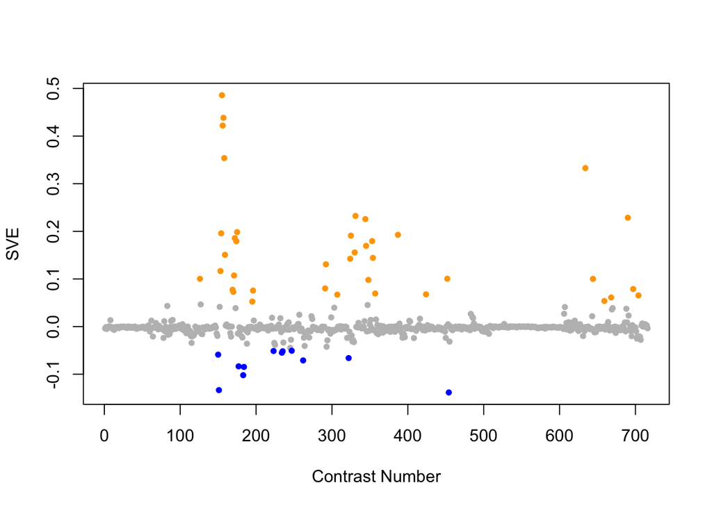

Positive SVE Contrasts:

|  | Contrast.Num | SVE | GEO.GSE | Cond.1 | Cond.2 | Mutation |
| --- | --- | --- | --- | --- | --- | --- |
| GSE47778.s1t1.vs.s2t1 | 155 | 0.49 | GSE47778 | N2; replicate 1 | daf-2; replicate 1 | daf-2 |
| GSE47778.s1t1.vs.s4t1 | 157 | 0.44 | GSE47778 | N2; replicate 1 | daf-2;daf-16; replicate 1 | daf-2;daf-16 |
| GSE47778.s5t1.vs.s2t1 | 156 | 0.42 | GSE47778 | xpa-1 0mJ/cm2; replicate 1 | daf-2; replicate 1 | xpa-1 vs. daf-2 |
| GSE47778.s5t1.vs.s4t1 | 158 | 0.35 | GSE47778 | xpa-1 0mJ/cm2; replicate 1 | daf-2;daf-16; replicate 1 | xpa-1 vs. daf-2;daf-16 |
| GSE19138.s1t1.vs.s0t1 | 634 | 0.33 | GSE19138 | ALG-1(-) 1 | WT1 | alg-1 |
| GSE38997.s4t4.vs.s3t4 | 331 | 0.23 | GSE38997 | experiment 1 UVC-exposed samples at 51 h 1u51 | experiment 1 UVC- and EtBr-exposed samples at 51 h 1eu51 |  |
| GSE11055.s1t6.vs.s2t6 | 690 | 0.23 | GSE11055 | L1 larvae 12 hr after hatching in the presence of food | L1 larvae 12 hr after hatching in the absence of food |  |
| GSE38997.s1t3.vs.s1t1 | 344 | 0.23 | GSE38997 | experiment 1 control samples at 48 h 1c48 | experiment 4 control samples at 3 h 4c3 |  |
| GSE47778.s5t3.vs.s1t3 | 175 | 0.20 | GSE47778 | xpa-1 10mJ/cm2; replicate 1 | N2; UV; replicate 1 | xpa-1 |
| GSE47778.s4t1.vs.s2t1 | 154 | 0.20 | GSE47778 | daf-2;daf-16; replicate 1 | daf-2; replicate 1 | daf-2;daf-16 vs. daf-2 |
| GSE34026.s1t1.vs.s0t1 | 387 | 0.19 | GSE34026 | N2 exposed to hemolysin mutant of E7946, biological rep1 | N2 exposed to OP50(E.coli), biological rep1 |  |
| GSE38997.s4t3.vs.s3t3 | 325 | 0.19 | GSE38997 | experiment 1 UVC-exposed samples at 48 h 1u48 | experiment 1 UVC- and EtBr-exposed samples at 48 h 1eu48 |  |
| GSE47778.s5t3.vs.s2t3 | 172 | 0.19 | GSE47778 | xpa-1 10mJ/cm2; replicate 1 | daf-2; UV; replicate 1 | xpa-1 vs. daf-2 |
| GSE38997.s4t3.vs.s4t1 | 353 | 0.18 | GSE38997 | experiment 1 UVC-exposed samples at 48 h 1u48 | experiment 4 UVC-exposed samples at 3 h 4u3 |  |
| GSE47778.s5t3.vs.s4t3 | 174 | 0.18 | GSE47778 | xpa-1 10mJ/cm2; replicate 1 | daf-2;daf-16; UV; replicate 1 | xpa-1 vs. daf-2;daf-16 |
| GSE38997.s1t4.vs.s1t1 | 345 | 0.17 | GSE38997 | experiment 1 control samples at 51 h 1c51 | experiment 4 control samples at 3 h 4c3 |  |
| GSE38997.s4t4.vs.s2t4 | 330 | 0.16 | GSE38997 | experiment 1 UVC-exposed samples at 51 h 1u51 | experiment 1 EtBr-exposed samples at 51 h 1e51 |  |
| GSE47778.s5t1.vs.s1t1 | 159 | 0.15 | GSE47778 | xpa-1 0mJ/cm2; replicate 1 | N2; replicate 1 | xpa-1 |
| GSE38997.s4t4.vs.s4t1 | 354 | 0.14 | GSE38997 | experiment 1 UVC-exposed samples at 51 h 1u51 | experiment 4 UVC-exposed samples at 3 h 4u3 |  |
| GSE38997.s4t3.vs.s2t3 | 324 | 0.14 | GSE38997 | experiment 1 UVC-exposed samples at 48 h 1u48 | experiment 1 EtBr-exposed samples at 48 h 1e48 |  |
| GSE41366C.s1t2.vs.s0t2 | 292 | 0.13 | GSE41366 | low_DDVP-continuous_expose-8h_harvest-rep1 | control-continuous_expose-2h_harvest-rep1 |  |
| GSE47778.s5t1.vs.s3t1 | 153 | 0.12 | GSE47778 | xpa-1 0mJ/cm2; replicate 1 | daf-16; replicate 1 | xpa-1 vs. daf-16 |
| GSE47778.s1t3.vs.s2t3 | 171 | 0.11 | GSE47778 | N2; UV; replicate 1 | daf-2; UV; replicate 1 | daf-2 |
| GSE25633.s1t1.vs.s2t1 | 452 | 0.10 | GSE25633 | WT#1 | daf-19,daf-12#1 | daf-19;daf-12 |
| GSE54011.s1t1.vs.s0t1 | 126 | 0.10 | GSE54011 | Ce 0.05 mM Se | Ce 0 mM Se |  |
| GSE16915.s1t1.vs.s3t1 | 644 | 0.10 | GSE16915 | control sample | bio-electrosprayed sample |  |
| GSE38997.s2t4.vs.s2t1 | 348 | 0.10 | GSE38997 | experiment 1 EtBr-exposed samples at 51 h 1e51 | experiment 4 EtBr-exposed samples at 3 h 4e3 |  |
| GSE41366C.s2t2.vs.s0t2 | 291 | 0.08 | GSE41366 | high_DDVP-continuous_expose-8h_harvest-rep1 | control-continuous_expose-2h_harvest-rep1 |  |
| GSE11055.s1t8.vs.s2t8 | 697 | 0.08 | GSE11055 | L2 larvae 24 hr after hatching in the presence of food | L1 larvae 24 hr after hatching in the absence of food |  |
| GSE47778.s5t3.vs.s3t3 | 169 | 0.08 | GSE47778 | xpa-1 10mJ/cm2; replicate 1 | daf-16; UV; replicate 1 | xpa-1 vs. daf-16 |
| GSE43959.s1t1.vs.s3t1 | 196 | 0.08 | GSE43959 | N2 young adult on E. coli OP50 rep 1 | N2 young adult on Comamonas DA1877 rep 1 |  |
| GSE47778.s4t3.vs.s2t3 | 170 | 0.07 | GSE47778 | daf-2;daf-16; UV; replicate 1 | daf-2; UV; replicate 1 | daf-2;daf-16 vs. daf-2 |
| GSE38196.s1t2.vs.s0t2 | 357 | 0.07 | GSE38196 | atfs-1(tm4525)-treated, biological rep1 | wild-type-treated, biological rep1 | afts-1 |
| GSE27867.s1t1.vs.s0t1 | 424 | 0.07 | GSE27867 | tag-24, biological rep1 | wt, biological rep1 | tag-24 |
| GSE41366C.s1t2.vs.s1t1 | 307 | 0.07 | GSE41366 | low_DDVP-continuous_expose-8h_harvest-rep1 | low_DDVP-continuous_expose-2h_harvest-rep1 |  |
| GSE11055.s1t6.vs.s1t1 | 704 | 0.07 | GSE11055 | L1 larvae 12 hr after hatching in the presence of food | embryo 2 hr before hatching |  |
| GSE15016.s4t1.vs.s0t1 | 668 | 0.06 | GSE15016 | young adult_24hr BPA exposure_rep1 | young adult_not exposured_rep1 |  |
| GSE15762.s1t1.vs.s0t1 | 659 | 0.05 | GSE15762 | hlh-30(tm1978)-1 | N2-1 | hlh-30 |
| GSE43959.s2t1.vs.s3t1 | 195 | 0.05 | GSE43959 | N2 young adult on E. coli HT115 rep 1 | N2 young adult on Comamonas DA1877 rep 1 |  |

Negative SVE Contrasts:

|  | Contrast.Num | SVE | GEO.GSE | Cond.1 | Cond.2 | Mutation |
| --- | --- | --- | --- | --- | --- | --- |
| GSE25513.s2t1.vs.s0t1 | 454 | -0.14 | GSE25513 | crh-1 null (1) | WT (1) | crh-1 |
| GSE47778.s4t1.vs.s3t1 | 151 | -0.13 | GSE47778 | daf-2;daf-16; replicate 1 | daf-16; replicate 1 | daf-2;daf-16 vs. daf-16 |
| GSE47778.s1t3.vs.s1t1 | 183 | -0.10 | GSE47778 | N2; UV; replicate 1 | N2; replicate 1 |  |
| GSE47778.s5t3.vs.s5t1 | 184 | -0.08 | GSE47778 | xpa-1 10mJ/cm2; replicate 1 | xpa-1 0mJ/cm2; replicate 1 |  |
| GSE47778.s3t3.vs.s3t1 | 177 | -0.08 | GSE47778 | daf-16; UV; replicate 1 | daf-16; replicate 1 |  |
| GSE41366A.s2t1.vs.s0t1 | 262 | -0.07 | GSE41366 | high_DDVP-2h_expose-8h_harvest-rep1 | control-2h_expose-8h_harvest-rep1 |  |
| GSE38997.s4t3.vs.s1t3 | 322 | -0.07 | GSE38997 | experiment 1 UVC-exposed samples at 48 h 1u48 | experiment 1 control samples at 48 h 1c48 |  |
| GSE47778.s2t1.vs.s3t1 | 150 | -0.06 | GSE47778 | daf-2; replicate 1 | daf-16; replicate 1 | daf-2 vs. daf-16 |
| GSE42592B.s3t3.vs.s3t2 | 234 | -0.05 | GSE42592 | cadmium_high_expose-8h_rep1 | cadmium_high_expose-4h_rep1 |  |
| GSE42592B.s1t3.vs.s1t2 | 235 | -0.05 | GSE42592 | cadmium_low_expose-8h_rep1 | cadmium_low_expose-4h_rep1 |  |
| GSE42592A.s3t3.vs.s3t2 | 223 | -0.05 | GSE42592 | acrylamide_high_expose-8h_rep1 | acrylamide_high_expose-4h_rep1 |  |
| GSE42592C.s2t3.vs.s2t2 | 247 | -0.05 | GSE42592 | mercury_mid_expose-8h_rep1 | mercury_mid_expose-4h_rep1 |  |

$~$

#### Contrast SVE, Down-Regulated Genes Only:

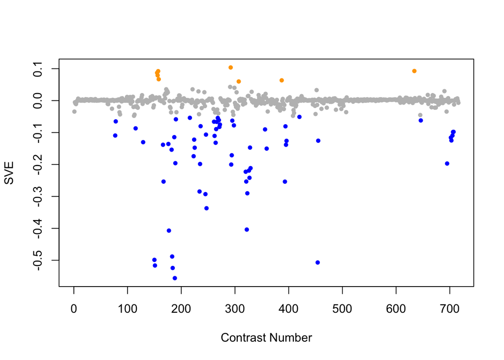

Positive SVE Contrasts:

|  | Contrast.Num | SVE | GEO.GSE | Cond.1 | Cond.2 | Mutation |
| --- | --- | --- | --- | --- | --- | --- |
| GSE41366C.s1t2.vs.s0t2 | 292 | 0.10 | GSE41366 | low_DDVP-continuous_expose-8h_harvest-rep1 | control-continuous_expose-2h_harvest-rep1 |  |
| GSE19138.s1t1.vs.s0t1 | 634 | 0.09 | GSE19138 | ALG-1(-) 1 | WT1 | alg-1 |
| GSE47778.s1t1.vs.s4t1 | 157 | 0.09 | GSE47778 | N2; replicate 1 | daf-2;daf-16; replicate 1 | daf-2;daf-16 |
| GSE47778.s1t1.vs.s2t1 | 155 | 0.09 | GSE47778 | N2; replicate 1 | daf-2; replicate 1 | daf-2 |
| GSE47778.s5t1.vs.s2t1 | 156 | 0.08 | GSE47778 | xpa-1 0mJ/cm2; replicate 1 | daf-2; replicate 1 | xpa-1 vs. daf-2 |
| GSE47778.s5t1.vs.s4t1 | 158 | 0.07 | GSE47778 | xpa-1 0mJ/cm2; replicate 1 | daf-2;daf-16; replicate 1 | xpa-1 vs. daf-2;daf-16 |
| GSE34026.s1t1.vs.s0t1 | 387 | 0.06 | GSE34026 | N2 exposed to hemolysin mutant of E7946, biological rep1 | N2 exposed to OP50(E.coli), biological rep1 |  |
| GSE41366C.s1t2.vs.s1t1 | 307 | 0.06 | GSE41366 | low_DDVP-continuous_expose-8h_harvest-rep1 | low_DDVP-continuous_expose-2h_harvest-rep1 |  |

Negative SVE Contrasts:

|  | Contrast.Num | SVE | GEO.GSE | Cond.1 | Cond.2 | Mutation |
| --- | --- | --- | --- | --- | --- | --- |
| GSE46291.s2t1.vs.s1t1 | 188 | -0.56 | GSE46291 | L3-lethargus_rep1 | L3_rep1 |  |
| GSE47778.s5t3.vs.s5t1 | 184 | -0.52 | GSE47778 | xpa-1 10mJ/cm2; replicate 1 | xpa-1 0mJ/cm2; replicate 1 |  |
| GSE47778.s4t1.vs.s3t1 | 151 | -0.52 | GSE47778 | daf-2;daf-16; replicate 1 | daf-16; replicate 1 | daf-2;daf-16 vs. daf-16 |
| GSE25513.s2t1.vs.s0t1 | 454 | -0.51 | GSE25513 | crh-1 null (1) | WT (1) | crh-1 |
| GSE47778.s2t1.vs.s3t1 | 150 | -0.50 | GSE47778 | daf-2; replicate 1 | daf-16; replicate 1 | daf-2 vs. daf-16 |
| GSE47778.s1t3.vs.s1t1 | 183 | -0.49 | GSE47778 | N2; UV; replicate 1 | N2; replicate 1 |  |
| GSE47778.s3t3.vs.s3t1 | 177 | -0.41 | GSE47778 | daf-16; UV; replicate 1 | daf-16; replicate 1 |  |
| GSE38997.s4t3.vs.s1t3 | 322 | -0.40 | GSE38997 | experiment 1 UVC-exposed samples at 48 h 1u48 | experiment 1 control samples at 48 h 1c48 |  |
| GSE42592C.s2t3.vs.s2t2 | 247 | -0.34 | GSE42592 | mercury_mid_expose-8h_rep1 | mercury_mid_expose-4h_rep1 |  |
| GSE42592C.s3t3.vs.s3t2 | 245 | -0.29 | GSE42592 | mercury_high_expose-8h_rep1 | mercury_high_expose-4h_rep1 |  |
| GSE38997.s3t3.vs.s2t3 | 323 | -0.29 | GSE38997 | experiment 1 UVC- and EtBr-exposed samples at 48 h 1eu48 | experiment 1 EtBr-exposed samples at 48 h 1e48 |  |
| GSE42592B.s3t3.vs.s3t2 | 234 | -0.28 | GSE42592 | cadmium_high_expose-8h_rep1 | cadmium_high_expose-4h_rep1 |  |
| GSE32339.s1t1.vs.s0t1 | 393 | -0.25 | GSE32339 | Larval Mutant, biological rep1 | Larval Wild-type, biological rep1 | nep-1 |
| GSE47778.s4t3.vs.s3t3 | 167 | -0.25 | GSE47778 | daf-2;daf-16; UV; replicate 1 | daf-16; UV; replicate 1 | daf-2;daf-16 vs. daf-16 |
| GSE38997.s3t3.vs.s1t3 | 321 | -0.25 | GSE38997 | experiment 1 UVC- and EtBr-exposed samples at 48 h 1eu48 | experiment 1 control samples at 48 h 1c48 |  |
| GSE38997.s3t4.vs.s1t4 | 327 | -0.24 | GSE38997 | experiment 1 UVC- and EtBr-exposed samples at 51 h 1eu51 | experiment 1 control samples at 51 h 1c51 |  |
| GSE38997.s2t3.vs.s1t3 | 320 | -0.22 | GSE38997 | experiment 1 EtBr-exposed samples at 48 h 1e48 | experiment 1 control samples at 48 h 1c48 |  |
| GSE38997.s2t4.vs.s1t4 | 326 | -0.22 | GSE38997 | experiment 1 EtBr-exposed samples at 51 h 1e51 | experiment 1 control samples at 51 h 1c51 |  |
| GSE38997.s3t4.vs.s2t4 | 329 | -0.21 | GSE38997 | experiment 1 UVC- and EtBr-exposed samples at 51 h 1eu51 | experiment 1 EtBr-exposed samples at 51 h 1e51 |  |
| GSE41366C.s2t3.vs.s0t3 | 293 | -0.20 | GSE41366 | high_DDVP-continuous_expose-14h_harvest-rep1 | control-continuous_expose-8h_harvest-rep1 |  |
| GSE42592B.s1t3.vs.s1t2 | 235 | -0.20 | GSE42592 | cadmium_low_expose-8h_rep1 | cadmium_low_expose-4h_rep1 |  |
| GSE11055.s1t7.vs.s4t7 | 695 | -0.20 | GSE11055 | L1-L2 larvae 15 hr after hatching in the presence of food | L1 larvae fed for 12 hr after hatching and then starved for 3 hr |  |
| GSE46291.s1t3.vs.s1t1 | 189 | -0.20 | GSE46291 | Adult_rep1 | L3_rep1 |  |
| GSE42592A.s3t3.vs.s3t2 | 223 | -0.17 | GSE42592 | acrylamide_high_expose-8h_rep1 | acrylamide_high_expose-4h_rep1 |  |
| GSE41366C.s1t3.vs.s0t3 | 294 | -0.17 | GSE41366 | low_DDVP-continuous_expose-14h_harvest-rep1 | control-continuous_expose-8h_harvest-rep1 |  |
| GSE47778.s1t2.vs.s1t1 | 182 | -0.15 | GSE47778 | N2; starvation; replicate 1 | N2; replicate 1 |  |
| GSE38196.s0t2.vs.s0t1 | 359 | -0.15 | GSE38196 | wild-type-treated, biological rep1 | wild-type-control, biological rep1 | spg-7(RNAi) |
| GSE42592A.s2t3.vs.s2t2 | 225 | -0.15 | GSE42592 | acrylamide_mid_expose-8h_rep1 | acrylamide_mid_expose-4h_rep1 |  |
| GSE38997.s4t4.vs.s1t4 | 328 | -0.15 | GSE38997 | experiment 1 UVC-exposed samples at 51 h 1u51 | experiment 1 control samples at 51 h 1c51 |  |
| GSE32339.s0t2.vs.s0t1 | 395 | -0.14 | GSE32339 | Adult Wild-type, biological rep1 | Larval Wild-type, biological rep1 |  |
| GSE47778.s2t3.vs.s3t3 | 166 | -0.14 | GSE47778 | daf-2; UV; replicate 1 | daf-16; UV; replicate 1 | daf-2 vs. daf-16 |
| GSE47778.s3t2.vs.s3t1 | 176 | -0.14 | GSE47778 | daf-16; starvation; replicate 1 | daf-16; replicate 1 |  |
| GSE41366A.s0t2.vs.s0t1 | 264 | -0.13 | GSE41366 | control-2h_expose-14h_harvest-rep1 | control-2h_expose-8h_harvest-rep1 |  |
| GSE54011.s4t1.vs.s0t1 | 129 | -0.13 | GSE54011 | Ce 0.4 mM Se | Ce 0 mM Se |  |
| GSE32031.s1t1.vs.s0t1 | 396 | -0.13 | GSE32031 | Exerimental (nhr-23 RNAi), biological rep1 | Control, biological rep1 | nhr-23 |
| GSE25513.s1t1.vs.s0t1 | 455 | -0.13 | GSE25513 | tax-6 null (1) | WT (1) | tax-6 |
| GSE11055.s1t3.vs.s1t1 | 703 | -0.12 | GSE11055 | L1 larvae 1 hr after hatching in the presence of food | embryo 2 hr before hatching |  |
| GSE42592A.s1t3.vs.s1t2 | 224 | -0.12 | GSE42592 | acrylamide_low_expose-8h_rep1 | acrylamide_low_expose-4h_rep1 |  |
| GSE11055.s1t2.vs.s1t1 | 702 | -0.12 | GSE11055 | L1 larvae 0 hr after hatching in the presence of food | embryo 2 hr before hatching |  |
| GSE46291.s2t2.vs.s1t2 | 187 | -0.11 | GSE46291 | L4-lethargus_rep1 | L4_rep1 |  |
| GSE41366A.s2t1.vs.s0t1 | 262 | -0.11 | GSE41366 | high_DDVP-2h_expose-8h_harvest-rep1 | control-2h_expose-8h_harvest-rep1 |  |
| GSE8004.s3t2.vs.s1t2 | 77 | -0.11 | GSE8004 | Larval Pan-neural, biological rep 1 of set 2 | Larval A-class, biological rep 1 of set 3 |  |
| GSE11055.s1t4.vs.s1t1 | 705 | -0.11 | GSE11055 | L1 larvae 3 hr after hatching in the presence of food | embryo 2 hr before hatching |  |
| GSE42592C.s1t3.vs.s1t2 | 246 | -0.11 | GSE42592 | mercury_low_expose-8h_rep1 | mercury_low_expose-4h_rep1 |  |
| GSE11055.s1t5.vs.s1t1 | 706 | -0.10 | GSE11055 | L1 larvae 6 hr after hatching in the presence of food | embryo 2 hr before hatching |  |
| GSE11055.s1t7.vs.s1t1 | 707 | -0.10 | GSE11055 | L1-L2 larvae 15 hr after hatching in the presence of food | embryo 2 hr before hatching |  |
| GSE38196.s1t1.vs.s0t1 | 356 | -0.09 | GSE38196 | atfs-1(tm4525)-control, biological rep1 | wild-type-control, biological rep1 | afts-1 |
| GSE41366A.s0t3.vs.s0t1 | 265 | -0.09 | GSE41366 | control-2h_expose-20h_harvest-rep1 | control-2h_expose-8h_harvest-rep1 |  |
| GSE54024.s1t1.vs.s5t1 | 115 | -0.09 | GSE54024 | Wild type young adults, biological rep 1 | ced-4(n1162) young adults, biological rep 1 | ced-4 |
| GSE41366A.s1t3.vs.s1t1 | 271 | -0.08 | GSE41366 | low_DDVP-2h_expose-20h_harvest-rep1 | low_DDVP-2h_expose-8h_harvest-rep1 |  |
| GSE32339.s1t2.vs.s1t1 | 394 | -0.08 | GSE32339 | Adult Mutant, biological rep1 | Larval Mutant, biological rep1 |  |
| GSE42592B.s2t3.vs.s2t2 | 236 | -0.08 | GSE42592 | cadmium_mid_expose-8h_rep1 | cadmium_mid_expose-4h_rep1 |  |
| GSE41366C.s0t2.vs.s0t1 | 298 | -0.08 | GSE41366 | control-continuous_expose-2h_harvest-rep1 | control-continuous_expose-0h_harvest-rep2 |  |
| GSE41366A.s1t4.vs.s1t1 | 272 | -0.07 | GSE41366 | low_DDVP-2h_expose-26h_harvest-rep1 | low_DDVP-2h_expose-8h_harvest-rep1 |  |
| GSE41366A.s0t4.vs.s0t1 | 266 | -0.07 | GSE41366 | control-2h_expose-26h_harvest-rep1 | control-2h_expose-8h_harvest-rep1 |  |
| GSE41366A.s1t4.vs.s0t4 | 261 | -0.07 | GSE41366 | low_DDVP-2h_expose-26h_harvest-rep1 | control-2h_expose-26h_harvest-rep1 |  |
| GSE8004.s2t2.vs.s1t2 | 78 | -0.07 | GSE8004 | Larval Reference, biological rep 1 of set 1 | Larval A-class, biological rep 1 of set 3 |  |
| GSE41366C.s0t4.vs.s0t1 | 295 | -0.06 | GSE41366 | control-continuous_expose-14h_harvest-rep1 | control-continuous_expose-0h_harvest-rep2 |  |
| GSE16915.s2t1.vs.s1t1 | 646 | -0.06 | GSE16915 | positive control (heat shock) | control sample |  |
| GSE41366A.s1t2.vs.s1t1 | 270 | -0.06 | GSE41366 | low_DDVP-2h_expose-14h_harvest-rep1 | low_DDVP-2h_expose-8h_harvest-rep1 |  |
| GSE46291.s1t2.vs.s1t1 | 190 | -0.06 | GSE46291 | L4_rep1 | L3_rep1 |  |
| GSE41366A.s2t3.vs.s2t1 | 268 | -0.05 | GSE41366 | high_DDVP-2h_expose-20h_harvest-rep1 | high_DDVP-2h_expose-8h_harvest-rep1 |  |
| GSE42592A.s1t2.vs.s0t2 | 216 | -0.05 | GSE42592 | acrylamide_low_expose-4h_rep1 | acrylamide_control_expose-4h_rep1 |  |
| GSE28494.s1t1.vs.s0t1 | 420 | -0.05 | GSE28494 | lin-54(n2990) embryo 1 | wild-type N2 embryo 1 | lin-54 |

$~$

$~$

#### GO Term Enrichment:

This analysis tests each hemi-module for enrichment of specific GO terms. Only gene-level annotations (e.g., as would be found on the gene’s page in Wormbase) are tested - the hierarchical structure of the GO ontology is not taken into account.

*Note: At least the top two most enriched terms from each GO domain (BP/MF/CC) are shown, even when not statistically significant.*

##### Enriched GO terms: Hemi-module A

| ID | GO.Term | GO Domain | Raw p-value | Adj p-value |
| --- | --- | --- | --- | --- |
| [GO_0006508](http://amigo.geneontology.org/amigo/term/GO:0006508) | proteolysis | BP | 5.82e-11 | 2.12e-07 |
| [GO_0010951](http://amigo.geneontology.org/amigo/term/GO:0010951) | negative regulation of endopeptidase activity | BP | 3.69e-10 | 6.73e-07 |
| [GO_0018996](http://amigo.geneontology.org/amigo/term/GO:0018996) | molting cycle, collagen and cuticulin-based cuticle | BP | 2.74e-07 | 3.33e-04 |
| [GO_0030206](http://amigo.geneontology.org/amigo/term/GO:0030206) | chondroitin sulfate biosynthetic process | BP | 9.75e-07 | 8.88e-04 |
| [GO_1902884](http://amigo.geneontology.org/amigo/term/GO:1902884) | positive regulation of response to oxidative stress | BP | 6.88e-06 | 4.90e-03 |
| [GO_0010466](http://amigo.geneontology.org/amigo/term/GO:0010466) | negative regulation of peptidase activity | BP | 8.07e-06 | 4.90e-03 |
| [GO_0072334](http://amigo.geneontology.org/amigo/term/GO:0072334) | UDP-galactose transmembrane transport | BP | 3.59e-05 | 1.87e-02 |
| [GO_0008237](http://amigo.geneontology.org/amigo/term/GO:0008237) | metallopeptidase activity | MF | 1.12e-10 | 2.29e-07 |
| [GO_0004867](http://amigo.geneontology.org/amigo/term/GO:0004867) | serine-type endopeptidase inhibitor activity | MF | 5.58e-10 | 4.04e-07 |
| [GO_0004222](http://amigo.geneontology.org/amigo/term/GO:0004222) | metalloendopeptidase activity | MF | 5.93e-10 | 4.04e-07 |
| [GO_0008233](http://amigo.geneontology.org/amigo/term/GO:0008233) | peptidase activity | MF | 1.80e-07 | 9.22e-05 |
| [GO_0042302](http://amigo.geneontology.org/amigo/term/GO:0042302) | structural constituent of cuticle | MF | 5.38e-07 | 2.20e-04 |
| [GO_0047756](http://amigo.geneontology.org/amigo/term/GO:0047756) | chondroitin 4-sulfotransferase activity | MF | 3.58e-06 | 1.22e-03 |
| [GO_0030414](http://amigo.geneontology.org/amigo/term/GO:0030414) | peptidase inhibitor activity | MF | 5.06e-06 | 1.48e-03 |
| [GO_0008146](http://amigo.geneontology.org/amigo/term/GO:0008146) | sulfotransferase activity | MF | 1.61e-05 | 4.10e-03 |
| [GO_0005459](http://amigo.geneontology.org/amigo/term/GO:0005459) | UDP-galactose transmembrane transporter activity | MF | 3.59e-05 | 7.32e-03 |
| [GO_0015165](http://amigo.geneontology.org/amigo/term/GO:0015165) | pyrimidine nucleotide-sugar transmembrane transporter activity | MF | 3.59e-05 | 7.32e-03 |
| [GO_0005515](http://amigo.geneontology.org/amigo/term/GO:0005515) | protein binding | MF | 9.66e-05 | 1.79e-02 |
| [GO_0016757](http://amigo.geneontology.org/amigo/term/GO:0016757) | transferase activity, transferring glycosyl groups | MF | 1.06e-04 | 1.81e-02 |
| [GO_0042329](http://amigo.geneontology.org/amigo/term/GO:0042329) | structural constituent of collagen and cuticulin-based cuticle | MF | 1.33e-04 | 2.09e-02 |
| [GO_0003676](http://amigo.geneontology.org/amigo/term/GO:0003676) | nucleic acid binding | MF | 2.81e-04 | 4.11e-02 |
| [GO_0004181](http://amigo.geneontology.org/amigo/term/GO:0004181) | metallocarboxypeptidase activity | MF | 3.47e-04 | 4.72e-02 |
| [GO_0048306](http://amigo.geneontology.org/amigo/term/GO:0048306) | calcium-dependent protein binding | MF | 5.63e-04 | 7.19e-02 |
| [GO_0003723](http://amigo.geneontology.org/amigo/term/GO:0003723) | RNA binding | MF | 6.51e-04 | 7.82e-02 |
| [GO_0005634](http://amigo.geneontology.org/amigo/term/GO:0005634) | nucleus | CC | 3.44e-12 | 3.19e-09 |
| [GO_0005576](http://amigo.geneontology.org/amigo/term/GO:0005576) | extracellular region | CC | 5.83e-08 | 2.71e-05 |
| [GO_0005581](http://amigo.geneontology.org/amigo/term/GO:0005581) | collagen trimer | CC | 7.92e-07 | 2.45e-04 |
| [GO_0005615](http://amigo.geneontology.org/amigo/term/GO:0005615) | extracellular space | CC | 7.31e-06 | 1.37e-03 |
| [GO_0005737](http://amigo.geneontology.org/amigo/term/GO:0005737) | cytoplasm | CC | 7.39e-06 | 1.37e-03 |
| [GO_0060102](http://amigo.geneontology.org/amigo/term/GO:0060102) | collagen and cuticulin-based cuticle extracellular matrix | CC | 2.58e-05 | 3.99e-03 |
| [GO_0016021](http://amigo.geneontology.org/amigo/term/GO:0016021) | integral component of membrane | CC | 5.11e-04 | 6.78e-02 |

##### Enriched GO terms: Hemi-module B

| ID | GO.Term | GO Domain | Raw p-value | Adj p-value |
| --- | --- | --- | --- | --- |
| [GO_0090136](http://amigo.geneontology.org/amigo/term/GO:0090136) | epithelial cell-cell adhesion | BP | 1.45e-02 | 9.99e-01 |
| [GO_0006814](http://amigo.geneontology.org/amigo/term/GO:0006814) | sodium ion transport | BP | 1.72e-02 | 9.99e-01 |
| [GO_0004167](http://amigo.geneontology.org/amigo/term/GO:0004167) | dopachrome isomerase activity | MF | 3.66e-03 | 1.00e+00 |
| [GO_0004714](http://amigo.geneontology.org/amigo/term/GO:0004714) | transmembrane receptor protein tyrosine kinase activity | MF | 6.05e-03 | 1.00e+00 |
| [GO_0005737](http://amigo.geneontology.org/amigo/term/GO:0005737) | cytoplasm | CC | 1.21e-03 | 1.00e+00 |
| [GO_0043235](http://amigo.geneontology.org/amigo/term/GO:0043235) | receptor complex | CC | 9.33e-03 | 1.00e+00 |

$~$

$~$

#### Tissue Enrichment:

This analysis tests each hemi-module for enrichment of genes associated with anatomy terms. Negative enrichment scores indicate fewer hemi-module genes than expected by random chance were associated with the anatomy term in question.

##### Enriched tissues: Hemi-module A

| ID | Anatomy.Term | Definition | Raw p-value | Adj p-value |
| --- | --- | --- | --- | --- |
| [WBbt_0005734](https://wormbase.org/species/all/anatomy_term/WBbt:0005734) | hyp7 syncytium | entire syncytium of hyp7 | 3.67e-06 | 5.66e-03 |
| [WBbt_0005753](https://wormbase.org/species/all/anatomy_term/WBbt:0005753) | seam cell | a group of hypodermal cells that lie along the apical midline of the hypodermis, at the extreme left and right sides between nose and tail | 4.65e-06 | 5.66e-03 |
| [WBbt_0004679](https://wormbase.org/species/all/anatomy_term/WBbt:0004679) | hyp6 | Cylindrical hypodermal syncytium in head | 1.42e-05 | 1.16e-02 |
| [WBbt_0004381](https://wormbase.org/species/all/anatomy_term/WBbt:0004381) | hyp8 | Tail ventral hypodermis, 8th hypodermis cell | 4.10e-05 | 2.25e-02 |
| [WBbt_0004380](https://wormbase.org/species/all/anatomy_term/WBbt:0004380) | hyp9 | Tail ventral hypodermis, 9th hypodermis cell | 4.63e-05 | 2.25e-02 |
| [WBbt_0004378](https://wormbase.org/species/all/anatomy_term/WBbt:0004378) | hyp10 | Tail ventral hypodermis | 1.01e-04 | 4.09e-02 |
| [WBbt_0004377](https://wormbase.org/species/all/anatomy_term/WBbt:0004377) | hyp11 | Tail dorsal hypodermis | 2.68e-04 | 9.33e-02 |
| [WBbt_0004685](https://wormbase.org/species/all/anatomy_term/WBbt:0004685) | hyp5 | Cylindrical hypodermal syncytium in head | 3.16e-04 | 9.62e-02 |

##### Enriched tissues: Hemi-module B

No significant annotations.

$~$

$~$

#### HOMER promoter motif enrichment:

This analysis tests each hemi-module for enrichment of 108 known *C. elegans* transcription factor binding site motifs (see [108 CE motifs](https://katiepod.github.io//all.worm.motifs.html)) using the HOMER (Hypergeometric Optimization of Motif EnRichment) software (see [PMID:20513432](https://pubmed.ncbi.nlm.nih.gov/20513432)). HOMER was run using default parameters on sequences 1 kb upstream of the transcription start site.

##### Motif enrichment: Hemi-module A

Total target sequences = 459  
Total background sequences = 40894  
* - possible false positive

Rank

Motif

P-value

log P-pvalue

% of Targets

% of Background

STD(Bg STD)

Best Match/Details

Motif File

1

[figure not shown]

1e-12

-2.857e+01

8.50%

2.07%

294.1bp (349.2bp)

MF0004.1_Nuclear_Receptor_class/Jaspar(0.641)  
[More Information](https://katiepod.github.io/HomerResults/m78_a_hemi_genes.txt.out.1kb/homerResults/motif1.info.html) | [Similar Motifs Found](https://katiepod.github.io/HomerResults/m78_a_hemi_genes.txt.out.1kb/homerResults/motif1.similar.html)

[motif file (matrix)](https://katiepod.github.io/HomerResults/m78_a_hemi_genes.txt.out.1kb/homerResults/motif1.motif)

2 *

[figure not shown]

1e-11

-2.746e+01

3.70%

0.32%

274.4bp (299.1bp)

lin-54/MA1450.1/Jaspar(0.647)  
[More Information](https://katiepod.github.io/HomerResults/m78_a_hemi_genes.txt.out.1kb/homerResults/motif2.info.html) | [Similar Motifs Found](https://katiepod.github.io/HomerResults/m78_a_hemi_genes.txt.out.1kb/homerResults/motif2.similar.html)

[motif file (matrix)](https://katiepod.github.io/HomerResults/m78_a_hemi_genes.txt.out.1kb/homerResults/motif2.motif)

3 *

[figure not shown]

1e-11

-2.681e+01

1.53%

0.01%

228.5bp (131.4bp)

unc-30/MA1443.1/Jaspar(0.576)  
[More Information](https://katiepod.github.io/HomerResults/m78_a_hemi_genes.txt.out.1kb/homerResults/motif3.info.html) | [Similar Motifs Found](https://katiepod.github.io/HomerResults/m78_a_hemi_genes.txt.out.1kb/homerResults/motif3.similar.html)

[motif file (matrix)](https://katiepod.github.io/HomerResults/m78_a_hemi_genes.txt.out.1kb/homerResults/motif3.motif)

4 *

[figure not shown]

1e-11

-2.602e+01

4.58%

0.61%

286.5bp (359.4bp)

POL011.1_XCPE1/Jaspar(0.682)  
[More Information](https://katiepod.github.io/HomerResults/m78_a_hemi_genes.txt.out.1kb/homerResults/motif4.info.html) | [Similar Motifs Found](https://katiepod.github.io/HomerResults/m78_a_hemi_genes.txt.out.1kb/homerResults/motif4.similar.html)

[motif file (matrix)](https://katiepod.github.io/HomerResults/m78_a_hemi_genes.txt.out.1kb/homerResults/motif4.motif)

5 *

[figure not shown]

1e-11

-2.572e+01

4.36%

0.56%

245.7bp (317.0bp)

SA0001.1_at_AC_acceptor/Jaspar(0.564)  
[More Information](https://katiepod.github.io/HomerResults/m78_a_hemi_genes.txt.out.1kb/homerResults/motif5.info.html) | [Similar Motifs Found](https://katiepod.github.io/HomerResults/m78_a_hemi_genes.txt.out.1kb/homerResults/motif5.similar.html)

[motif file (matrix)](https://katiepod.github.io/HomerResults/m78_a_hemi_genes.txt.out.1kb/homerResults/motif5.motif)

6 *

[figure not shown]

1e-10

-2.514e+01

4.36%

0.58%

278.3bp (314.0bp)

mab-3/MA0262.1/Jaspar(0.586)  
[More Information](https://katiepod.github.io/HomerResults/m78_a_hemi_genes.txt.out.1kb/homerResults/motif6.info.html) | [Similar Motifs Found](https://katiepod.github.io/HomerResults/m78_a_hemi_genes.txt.out.1kb/homerResults/motif6.similar.html)

[motif file (matrix)](https://katiepod.github.io/HomerResults/m78_a_hemi_genes.txt.out.1kb/homerResults/motif6.motif)

7 *

[figure not shown]

1e-10

-2.497e+01

3.05%

0.23%

301.3bp (326.7bp)

POL008.1_DCE_S_I/Jaspar(0.534)  
[More Information](https://katiepod.github.io/HomerResults/m78_a_hemi_genes.txt.out.1kb/homerResults/motif7.info.html) | [Similar Motifs Found](https://katiepod.github.io/HomerResults/m78_a_hemi_genes.txt.out.1kb/homerResults/motif7.similar.html)

[motif file (matrix)](https://katiepod.github.io/HomerResults/m78_a_hemi_genes.txt.out.1kb/homerResults/motif7.motif)

8 *

[figure not shown]

1e-10

-2.424e+01

6.10%

1.27%

201.5bp (353.8bp)

efl-1/MA0541.1/Jaspar(0.683)  
[More Information](https://katiepod.github.io/HomerResults/m78_a_hemi_genes.txt.out.1kb/homerResults/motif8.info.html) | [Similar Motifs Found](https://katiepod.github.io/HomerResults/m78_a_hemi_genes.txt.out.1kb/homerResults/motif8.similar.html)

[motif file (matrix)](https://katiepod.github.io/HomerResults/m78_a_hemi_genes.txt.out.1kb/homerResults/motif8.motif)

9 *

[figure not shown]

1e-10

-2.398e+01

24.40%

13.01%

291.5bp (321.9bp)

MF0001.1_ETS_class/Jaspar(0.707)  
[More Information](https://katiepod.github.io/HomerResults/m78_a_hemi_genes.txt.out.1kb/homerResults/motif9.info.html) | [Similar Motifs Found](https://katiepod.github.io/HomerResults/m78_a_hemi_genes.txt.out.1kb/homerResults/motif9.similar.html)

[motif file (matrix)](https://katiepod.github.io/HomerResults/m78_a_hemi_genes.txt.out.1kb/homerResults/motif9.motif)

10 *

[figure not shown]

1e-10

-2.390e+01

9.37%

2.89%

266.6bp (308.9bp)

ceh-22/MA0264.1/Jaspar(0.633)  
[More Information](https://katiepod.github.io/HomerResults/m78_a_hemi_genes.txt.out.1kb/homerResults/motif10.info.html) | [Similar Motifs Found](https://katiepod.github.io/HomerResults/m78_a_hemi_genes.txt.out.1kb/homerResults/motif10.similar.html)

[motif file (matrix)](https://katiepod.github.io/HomerResults/m78_a_hemi_genes.txt.out.1kb/homerResults/motif10.motif)

11 *

[figure not shown]

1e-10

-2.344e+01

6.97%

1.71%

284.3bp (317.2bp)

PL0001.1_hlh-11/Jaspar(0.623)  
[More Information](https://katiepod.github.io/HomerResults/m78_a_hemi_genes.txt.out.1kb/homerResults/motif11.info.html) | [Similar Motifs Found](https://katiepod.github.io/HomerResults/m78_a_hemi_genes.txt.out.1kb/homerResults/motif11.similar.html)

[motif file (matrix)](https://katiepod.github.io/HomerResults/m78_a_hemi_genes.txt.out.1kb/homerResults/motif11.motif)

12 *

[figure not shown]

1e-9

-2.203e+01

13.07%

5.32%

261.3bp (319.7bp)

PL0009.1_hlh-26/Jaspar(0.718)  
[More Information](https://katiepod.github.io/HomerResults/m78_a_hemi_genes.txt.out.1kb/homerResults/motif12.info.html) | [Similar Motifs Found](https://katiepod.github.io/HomerResults/m78_a_hemi_genes.txt.out.1kb/homerResults/motif12.similar.html)

[motif file (matrix)](https://katiepod.github.io/HomerResults/m78_a_hemi_genes.txt.out.1kb/homerResults/motif12.motif)

13 *

[figure not shown]

1e-9

-2.187e+01

3.05%

0.29%

239.0bp (317.6bp)

LIN-39(Homeobox)/cElegans.L3-LIN39-ChIP-Seq(modEncode)/Homer(0.764)  
[More Information](https://katiepod.github.io/HomerResults/m78_a_hemi_genes.txt.out.1kb/homerResults/motif13.info.html) | [Similar Motifs Found](https://katiepod.github.io/HomerResults/m78_a_hemi_genes.txt.out.1kb/homerResults/motif13.similar.html)

[motif file (matrix)](https://katiepod.github.io/HomerResults/m78_a_hemi_genes.txt.out.1kb/homerResults/motif13.motif)

14 *

[figure not shown]

1e-9

-2.180e+01

19.39%

9.71%

259.1bp (333.2bp)

LIN-39(Homeobox)/cElegans.L3-LIN39-ChIP-Seq(modEncode)/Homer(0.726)  
[More Information](https://katiepod.github.io/HomerResults/m78_a_hemi_genes.txt.out.1kb/homerResults/motif14.info.html) | [Similar Motifs Found](https://katiepod.github.io/HomerResults/m78_a_hemi_genes.txt.out.1kb/homerResults/motif14.similar.html)

[motif file (matrix)](https://katiepod.github.io/HomerResults/m78_a_hemi_genes.txt.out.1kb/homerResults/motif14.motif)

15 *

[figure not shown]

1e-9

-2.146e+01

6.10%

1.44%

271.3bp (303.9bp)

nhr-6/MA1451.1/Jaspar(0.622)  
[More Information](https://katiepod.github.io/HomerResults/m78_a_hemi_genes.txt.out.1kb/homerResults/motif15.info.html) | [Similar Motifs Found](https://katiepod.github.io/HomerResults/m78_a_hemi_genes.txt.out.1kb/homerResults/motif15.similar.html)

[motif file (matrix)](https://katiepod.github.io/HomerResults/m78_a_hemi_genes.txt.out.1kb/homerResults/motif15.motif)

16 *

[figure not shown]

1e-8

-2.003e+01

3.92%

0.62%

175.5bp (341.5bp)

fos-1/MA1448.1/Jaspar(0.668)  
[More Information](https://katiepod.github.io/HomerResults/m78_a_hemi_genes.txt.out.1kb/homerResults/motif16.info.html) | [Similar Motifs Found](https://katiepod.github.io/HomerResults/m78_a_hemi_genes.txt.out.1kb/homerResults/motif16.similar.html)

[motif file (matrix)](https://katiepod.github.io/HomerResults/m78_a_hemi_genes.txt.out.1kb/homerResults/motif16.motif)

17 *

[figure not shown]

1e-8

-1.978e+01

32.24%

20.43%

287.3bp (322.4bp)

SD0003.1_at_AC_acceptor/Jaspar(0.709)  
[More Information](https://katiepod.github.io/HomerResults/m78_a_hemi_genes.txt.out.1kb/homerResults/motif17.info.html) | [Similar Motifs Found](https://katiepod.github.io/HomerResults/m78_a_hemi_genes.txt.out.1kb/homerResults/motif17.similar.html)

[motif file (matrix)](https://katiepod.github.io/HomerResults/m78_a_hemi_genes.txt.out.1kb/homerResults/motif17.motif)

18 *

[figure not shown]

1e-8

-1.974e+01

5.45%

1.26%

285.2bp (306.2bp)

ces-2/MA0922.1/Jaspar(0.671)  
[More Information](https://katiepod.github.io/HomerResults/m78_a_hemi_genes.txt.out.1kb/homerResults/motif18.info.html) | [Similar Motifs Found](https://katiepod.github.io/HomerResults/m78_a_hemi_genes.txt.out.1kb/homerResults/motif18.similar.html)

[motif file (matrix)](https://katiepod.github.io/HomerResults/m78_a_hemi_genes.txt.out.1kb/homerResults/motif18.motif)

19 *

[figure not shown]

1e-8

-1.947e+01

11.55%

4.70%

288.6bp (329.9bp)

CES-1(Homeobox)/cElegans-L1-CES1-ChIP-Seq(modEncode)/Homer(0.521)  
[More Information](https://katiepod.github.io/HomerResults/m78_a_hemi_genes.txt.out.1kb/homerResults/motif19.info.html) | [Similar Motifs Found](https://katiepod.github.io/HomerResults/m78_a_hemi_genes.txt.out.1kb/homerResults/motif19.similar.html)

[motif file (matrix)](https://katiepod.github.io/HomerResults/m78_a_hemi_genes.txt.out.1kb/homerResults/motif19.motif)

20 *

[figure not shown]

1e-8

-1.943e+01

8.50%

2.86%

292.2bp (339.1bp)

MF0004.1_Nuclear_Receptor_class/Jaspar(0.560)  
[More Information](https://katiepod.github.io/HomerResults/m78_a_hemi_genes.txt.out.1kb/homerResults/motif20.info.html) | [Similar Motifs Found](https://katiepod.github.io/HomerResults/m78_a_hemi_genes.txt.out.1kb/homerResults/motif20.similar.html)

[motif file (matrix)](https://katiepod.github.io/HomerResults/m78_a_hemi_genes.txt.out.1kb/homerResults/motif20.motif)

21 *

[figure not shown]

1e-8

-1.898e+01

5.01%

1.11%

294.9bp (306.3bp)

POL008.1_DCE_S_I/Jaspar(0.578)  
[More Information](https://katiepod.github.io/HomerResults/m78_a_hemi_genes.txt.out.1kb/homerResults/motif21.info.html) | [Similar Motifs Found](https://katiepod.github.io/HomerResults/m78_a_hemi_genes.txt.out.1kb/homerResults/motif21.similar.html)

[motif file (matrix)](https://katiepod.github.io/HomerResults/m78_a_hemi_genes.txt.out.1kb/homerResults/motif21.motif)

22 *

[figure not shown]

1e-8

-1.867e+01

1.74%

0.07%

193.0bp (305.8bp)

MF0010.1_Homeobox_class/Jaspar(0.591)  
[More Information](https://katiepod.github.io/HomerResults/m78_a_hemi_genes.txt.out.1kb/homerResults/motif22.info.html) | [Similar Motifs Found](https://katiepod.github.io/HomerResults/m78_a_hemi_genes.txt.out.1kb/homerResults/motif22.similar.html)

[motif file (matrix)](https://katiepod.github.io/HomerResults/m78_a_hemi_genes.txt.out.1kb/homerResults/motif22.motif)

23 *

[figure not shown]

1e-7

-1.774e+01

1.09%

0.01%

313.4bp (204.9bp)

cebp-1/MA1444.1/Jaspar(0.556)  
[More Information](https://katiepod.github.io/HomerResults/m78_a_hemi_genes.txt.out.1kb/homerResults/motif23.info.html) | [Similar Motifs Found](https://katiepod.github.io/HomerResults/m78_a_hemi_genes.txt.out.1kb/homerResults/motif23.similar.html)

[motif file (matrix)](https://katiepod.github.io/HomerResults/m78_a_hemi_genes.txt.out.1kb/homerResults/motif23.motif)

24 *

[figure not shown]

1e-7

-1.760e+01

12.20%

5.42%

296.7bp (333.9bp)

elt-2/MA1701.1/Jaspar(0.886)  
[More Information](https://katiepod.github.io/HomerResults/m78_a_hemi_genes.txt.out.1kb/homerResults/motif24.info.html) | [Similar Motifs Found](https://katiepod.github.io/HomerResults/m78_a_hemi_genes.txt.out.1kb/homerResults/motif24.similar.html)

[motif file (matrix)](https://katiepod.github.io/HomerResults/m78_a_hemi_genes.txt.out.1kb/homerResults/motif24.motif)

25 *

[figure not shown]

1e-7

-1.744e+01

1.74%

0.09%

293.3bp (288.0bp)

blmp-1/MA0537.1/Jaspar(0.626)  
[More Information](https://katiepod.github.io/HomerResults/m78_a_hemi_genes.txt.out.1kb/homerResults/motif25.info.html) | [Similar Motifs Found](https://katiepod.github.io/HomerResults/m78_a_hemi_genes.txt.out.1kb/homerResults/motif25.similar.html)

[motif file (matrix)](https://katiepod.github.io/HomerResults/m78_a_hemi_genes.txt.out.1kb/homerResults/motif25.motif)

26 *

[figure not shown]

1e-7

-1.713e+01

8.93%

3.38%

277.4bp (302.5bp)

MF0011.1_HMG_class/Jaspar(0.640)  
[More Information](https://katiepod.github.io/HomerResults/m78_a_hemi_genes.txt.out.1kb/homerResults/motif26.info.html) | [Similar Motifs Found](https://katiepod.github.io/HomerResults/m78_a_hemi_genes.txt.out.1kb/homerResults/motif26.similar.html)

[motif file (matrix)](https://katiepod.github.io/HomerResults/m78_a_hemi_genes.txt.out.1kb/homerResults/motif26.motif)

27 *

[figure not shown]

1e-6

-1.535e+01

14.38%

7.36%

297.7bp (325.5bp)

MF0011.1_HMG_class/Jaspar(0.722)  
[More Information](https://katiepod.github.io/HomerResults/m78_a_hemi_genes.txt.out.1kb/homerResults/motif27.info.html) | [Similar Motifs Found](https://katiepod.github.io/HomerResults/m78_a_hemi_genes.txt.out.1kb/homerResults/motif27.similar.html)

[motif file (matrix)](https://katiepod.github.io/HomerResults/m78_a_hemi_genes.txt.out.1kb/homerResults/motif27.motif)

28 *

[figure not shown]

1e-6

-1.516e+01

2.18%

0.23%

268.0bp (273.1bp)

efl-1/MA0541.1/Jaspar(0.554)  
[More Information](https://katiepod.github.io/HomerResults/m78_a_hemi_genes.txt.out.1kb/homerResults/motif28.info.html) | [Similar Motifs Found](https://katiepod.github.io/HomerResults/m78_a_hemi_genes.txt.out.1kb/homerResults/motif28.similar.html)

[motif file (matrix)](https://katiepod.github.io/HomerResults/m78_a_hemi_genes.txt.out.1kb/homerResults/motif28.motif)

29 *

[figure not shown]

1e-6

-1.469e+01

5.66%

1.77%

252.6bp (328.2bp)

POL004.1_CCAAT-box/Jaspar(0.559)  
[More Information](https://katiepod.github.io/HomerResults/m78_a_hemi_genes.txt.out.1kb/homerResults/motif29.info.html) | [Similar Motifs Found](https://katiepod.github.io/HomerResults/m78_a_hemi_genes.txt.out.1kb/homerResults/motif29.similar.html)

[motif file (matrix)](https://katiepod.github.io/HomerResults/m78_a_hemi_genes.txt.out.1kb/homerResults/motif29.motif)

30 *

[figure not shown]

1e-6

-1.443e+01

17.43%

9.87%

237.5bp (363.0bp)

POL003.1_GC-box/Jaspar(0.772)  
[More Information](https://katiepod.github.io/HomerResults/m78_a_hemi_genes.txt.out.1kb/homerResults/motif30.info.html) | [Similar Motifs Found](https://katiepod.github.io/HomerResults/m78_a_hemi_genes.txt.out.1kb/homerResults/motif30.similar.html)

[motif file (matrix)](https://katiepod.github.io/HomerResults/m78_a_hemi_genes.txt.out.1kb/homerResults/motif30.motif)

31 *

[figure not shown]

1e-5

-1.360e+01

1.09%

0.03%

245.9bp (349.2bp)

MF0004.1_Nuclear_Receptor_class/Jaspar(0.639)  
[More Information](https://katiepod.github.io/HomerResults/m78_a_hemi_genes.txt.out.1kb/homerResults/motif31.info.html) | [Similar Motifs Found](https://katiepod.github.io/HomerResults/m78_a_hemi_genes.txt.out.1kb/homerResults/motif31.similar.html)

[motif file (matrix)](https://katiepod.github.io/HomerResults/m78_a_hemi_genes.txt.out.1kb/homerResults/motif31.motif)

32 *

[figure not shown]

1e-5

-1.261e+01

3.70%

0.94%

303.0bp (306.0bp)

fkh-9/MA1440.1/Jaspar(0.609)  
[More Information](https://katiepod.github.io/HomerResults/m78_a_hemi_genes.txt.out.1kb/homerResults/motif32.info.html) | [Similar Motifs Found](https://katiepod.github.io/HomerResults/m78_a_hemi_genes.txt.out.1kb/homerResults/motif32.similar.html)

[motif file (matrix)](https://katiepod.github.io/HomerResults/m78_a_hemi_genes.txt.out.1kb/homerResults/motif32.motif)

33 *

[figure not shown]

1e-5

-1.192e+01

1.31%

0.09%

192.6bp (316.6bp)

ceh-22/MA0264.1/Jaspar(0.561)  
[More Information](https://katiepod.github.io/HomerResults/m78_a_hemi_genes.txt.out.1kb/homerResults/motif33.info.html) | [Similar Motifs Found](https://katiepod.github.io/HomerResults/m78_a_hemi_genes.txt.out.1kb/homerResults/motif33.similar.html)

[motif file (matrix)](https://katiepod.github.io/HomerResults/m78_a_hemi_genes.txt.out.1kb/homerResults/motif33.motif)

34 *

[figure not shown]

1e-5

-1.153e+01

27.89%

19.49%

279.3bp (318.6bp)

lin-54/MA1450.1/Jaspar(0.562)  
[More Information](https://katiepod.github.io/HomerResults/m78_a_hemi_genes.txt.out.1kb/homerResults/motif34.info.html) | [Similar Motifs Found](https://katiepod.github.io/HomerResults/m78_a_hemi_genes.txt.out.1kb/homerResults/motif34.similar.html)

[motif file (matrix)](https://katiepod.github.io/HomerResults/m78_a_hemi_genes.txt.out.1kb/homerResults/motif34.motif)

35 *

[figure not shown]

1e-3

-9.008e+00

0.44%

0.00%

39.0bp (0.0bp)

dpy-27/MA0540.1/Jaspar(0.477)  
[More Information](https://katiepod.github.io/HomerResults/m78_a_hemi_genes.txt.out.1kb/homerResults/motif35.info.html) | [Similar Motifs Found](https://katiepod.github.io/HomerResults/m78_a_hemi_genes.txt.out.1kb/homerResults/motif35.similar.html)

[motif file (matrix)](https://katiepod.github.io/HomerResults/m78_a_hemi_genes.txt.out.1kb/homerResults/motif35.motif)

36 *

[figure not shown]

1e-3

-7.087e+00

1.09%

0.15%

229.3bp (300.0bp)

fos-1/MA1448.1/Jaspar(0.581)  
[More Information](https://katiepod.github.io/HomerResults/m78_a_hemi_genes.txt.out.1kb/homerResults/motif36.info.html) | [Similar Motifs Found](https://katiepod.github.io/HomerResults/m78_a_hemi_genes.txt.out.1kb/homerResults/motif36.similar.html)

[motif file (matrix)](https://katiepod.github.io/HomerResults/m78_a_hemi_genes.txt.out.1kb/homerResults/motif36.motif)

37 *

[figure not shown]

1e-1

-4.503e+00

0.22%

0.00%

111.2bp (0.0bp)

POL010.1_DCE_S_III/Jaspar(0.501)  
[More Information](https://katiepod.github.io/HomerResults/m78_a_hemi_genes.txt.out.1kb/homerResults/motif37.info.html) | [Similar Motifs Found](https://katiepod.github.io/HomerResults/m78_a_hemi_genes.txt.out.1kb/homerResults/motif37.similar.html)

[motif file (matrix)](https://katiepod.github.io/HomerResults/m78_a_hemi_genes.txt.out.1kb/homerResults/motif37.motif)

##### Motif enrichment: Hemi-module B

Total target sequences = 67  
Total background sequences = 38848  
* - possible false positive

Rank

Motif

P-value

log P-pvalue

% of Targets

% of Background

STD(Bg STD)

Best Match/Details

Motif File

1

[figure not shown]

1e-12

-2.879e+01

22.39%

1.65%

289.7bp (324.1bp)

nhr-6/MA1451.1/Jaspar(0.649)  
[More Information](https://katiepod.github.io/HomerResults/m78_b_hemi_genes.txt.out.1kb/homerResults/motif1.info.html) | [Similar Motifs Found](https://katiepod.github.io/HomerResults/m78_b_hemi_genes.txt.out.1kb/homerResults/motif1.similar.html)

[motif file (matrix)](https://katiepod.github.io/HomerResults/m78_b_hemi_genes.txt.out.1kb/homerResults/motif1.motif)

2 *

[figure not shown]

1e-10

-2.494e+01

17.91%

1.12%

263.5bp (326.5bp)

skn-1/MA0547.1/Jaspar(0.631)  
[More Information](https://katiepod.github.io/HomerResults/m78_b_hemi_genes.txt.out.1kb/homerResults/motif2.info.html) | [Similar Motifs Found](https://katiepod.github.io/HomerResults/m78_b_hemi_genes.txt.out.1kb/homerResults/motif2.similar.html)

[motif file (matrix)](https://katiepod.github.io/HomerResults/m78_b_hemi_genes.txt.out.1kb/homerResults/motif2.motif)

3 *

[figure not shown]

1e-10

-2.306e+01

11.94%

0.33%

259.5bp (324.2bp)

LIN-39(Homeobox)/cElegans.L3-LIN39-ChIP-Seq(modEncode)/Homer(0.614)  
[More Information](https://katiepod.github.io/HomerResults/m78_b_hemi_genes.txt.out.1kb/homerResults/motif3.info.html) | [Similar Motifs Found](https://katiepod.github.io/HomerResults/m78_b_hemi_genes.txt.out.1kb/homerResults/motif3.similar.html)

[motif file (matrix)](https://katiepod.github.io/HomerResults/m78_b_hemi_genes.txt.out.1kb/homerResults/motif3.motif)

4 *

[figure not shown]

1e-9

-2.230e+01

8.96%

0.11%

215.5bp (290.5bp)

lin-54/MA1450.1/Jaspar(0.575)  
[More Information](https://katiepod.github.io/HomerResults/m78_b_hemi_genes.txt.out.1kb/homerResults/motif4.info.html) | [Similar Motifs Found](https://katiepod.github.io/HomerResults/m78_b_hemi_genes.txt.out.1kb/homerResults/motif4.similar.html)

[motif file (matrix)](https://katiepod.github.io/HomerResults/m78_b_hemi_genes.txt.out.1kb/homerResults/motif4.motif)

5 *

[figure not shown]

1e-9

-2.109e+01

14.93%

0.91%

249.5bp (293.8bp)

lin-54/MA1450.1/Jaspar(0.706)  
[More Information](https://katiepod.github.io/HomerResults/m78_b_hemi_genes.txt.out.1kb/homerResults/motif5.info.html) | [Similar Motifs Found](https://katiepod.github.io/HomerResults/m78_b_hemi_genes.txt.out.1kb/homerResults/motif5.similar.html)

[motif file (matrix)](https://katiepod.github.io/HomerResults/m78_b_hemi_genes.txt.out.1kb/homerResults/motif5.motif)

6 *

[figure not shown]

1e-8

-1.991e+01

32.84%

7.59%

306.7bp (323.9bp)

nhr-6/MA1451.1/Jaspar(0.688)  
[More Information](https://katiepod.github.io/HomerResults/m78_b_hemi_genes.txt.out.1kb/homerResults/motif6.info.html) | [Similar Motifs Found](https://katiepod.github.io/HomerResults/m78_b_hemi_genes.txt.out.1kb/homerResults/motif6.similar.html)

[motif file (matrix)](https://katiepod.github.io/HomerResults/m78_b_hemi_genes.txt.out.1kb/homerResults/motif6.motif)

7 *

[figure not shown]

1e-8

-1.984e+01

37.31%

9.97%

295.5bp (316.1bp)

blmp-1/MA0537.1/Jaspar(0.746)  
[More Information](https://katiepod.github.io/HomerResults/m78_b_hemi_genes.txt.out.1kb/homerResults/motif7.info.html) | [Similar Motifs Found](https://katiepod.github.io/HomerResults/m78_b_hemi_genes.txt.out.1kb/homerResults/motif7.similar.html)

[motif file (matrix)](https://katiepod.github.io/HomerResults/m78_b_hemi_genes.txt.out.1kb/homerResults/motif7.motif)

8 *

[figure not shown]

1e-8

-1.928e+01

11.94%

0.54%

274.9bp (308.1bp)

POL001.1_MTE/Jaspar(0.584)  
[More Information](https://katiepod.github.io/HomerResults/m78_b_hemi_genes.txt.out.1kb/homerResults/motif8.info.html) | [Similar Motifs Found](https://katiepod.github.io/HomerResults/m78_b_hemi_genes.txt.out.1kb/homerResults/motif8.similar.html)

[motif file (matrix)](https://katiepod.github.io/HomerResults/m78_b_hemi_genes.txt.out.1kb/homerResults/motif8.motif)

9 *

[figure not shown]

1e-7

-1.810e+01

16.42%

1.64%

237.8bp (313.7bp)

MF0004.1_Nuclear_Receptor_class/Jaspar(0.721)  
[More Information](https://katiepod.github.io/HomerResults/m78_b_hemi_genes.txt.out.1kb/homerResults/motif9.info.html) | [Similar Motifs Found](https://katiepod.github.io/HomerResults/m78_b_hemi_genes.txt.out.1kb/homerResults/motif9.similar.html)

[motif file (matrix)](https://katiepod.github.io/HomerResults/m78_b_hemi_genes.txt.out.1kb/homerResults/motif9.motif)

10 *

[figure not shown]

1e-7

-1.667e+01

23.88%

4.65%

279.6bp (310.6bp)

lim-7/MA1441.1/Jaspar(0.593)  
[More Information](https://katiepod.github.io/HomerResults/m78_b_hemi_genes.txt.out.1kb/homerResults/motif10.info.html) | [Similar Motifs Found](https://katiepod.github.io/HomerResults/m78_b_hemi_genes.txt.out.1kb/homerResults/motif10.similar.html)

[motif file (matrix)](https://katiepod.github.io/HomerResults/m78_b_hemi_genes.txt.out.1kb/homerResults/motif10.motif)

11 *

[figure not shown]

1e-7

-1.655e+01

19.40%

2.91%

272.2bp (321.9bp)

lin-14/MA0261.1/Jaspar(0.645)  
[More Information](https://katiepod.github.io/HomerResults/m78_b_hemi_genes.txt.out.1kb/homerResults/motif11.info.html) | [Similar Motifs Found](https://katiepod.github.io/HomerResults/m78_b_hemi_genes.txt.out.1kb/homerResults/motif11.similar.html)

[motif file (matrix)](https://katiepod.github.io/HomerResults/m78_b_hemi_genes.txt.out.1kb/homerResults/motif11.motif)

12 *

[figure not shown]

1e-6

-1.570e+01

17.91%

2.59%

309.8bp (302.1bp)

SD0003.1_at_AC_acceptor/Jaspar(0.703)  
[More Information](https://katiepod.github.io/HomerResults/m78_b_hemi_genes.txt.out.1kb/homerResults/motif12.info.html) | [Similar Motifs Found](https://katiepod.github.io/HomerResults/m78_b_hemi_genes.txt.out.1kb/homerResults/motif12.similar.html)

[motif file (matrix)](https://katiepod.github.io/HomerResults/m78_b_hemi_genes.txt.out.1kb/homerResults/motif12.motif)

13 *

[figure not shown]

1e-6

-1.500e+01

10.45%

0.64%

238.2bp (311.2bp)

POL009.1_DCE_S_II/Jaspar(0.636)  
[More Information](https://katiepod.github.io/HomerResults/m78_b_hemi_genes.txt.out.1kb/homerResults/motif13.info.html) | [Similar Motifs Found](https://katiepod.github.io/HomerResults/m78_b_hemi_genes.txt.out.1kb/homerResults/motif13.similar.html)

[motif file (matrix)](https://katiepod.github.io/HomerResults/m78_b_hemi_genes.txt.out.1kb/homerResults/motif13.motif)

14 *

[figure not shown]

1e-5

-1.293e+01

8.96%

0.56%

286.2bp (288.1bp)

pha-4/MA0546.1/Jaspar(0.592)  
[More Information](https://katiepod.github.io/HomerResults/m78_b_hemi_genes.txt.out.1kb/homerResults/motif14.info.html) | [Similar Motifs Found](https://katiepod.github.io/HomerResults/m78_b_hemi_genes.txt.out.1kb/homerResults/motif14.similar.html)

[motif file (matrix)](https://katiepod.github.io/HomerResults/m78_b_hemi_genes.txt.out.1kb/homerResults/motif14.motif)

15 *

[figure not shown]

1e-5

-1.261e+01

5.97%

0.14%

80.2bp (329.9bp)

fos-1/MA1448.1/Jaspar(0.558)  
[More Information](https://katiepod.github.io/HomerResults/m78_b_hemi_genes.txt.out.1kb/homerResults/motif15.info.html) | [Similar Motifs Found](https://katiepod.github.io/HomerResults/m78_b_hemi_genes.txt.out.1kb/homerResults/motif15.similar.html)

[motif file (matrix)](https://katiepod.github.io/HomerResults/m78_b_hemi_genes.txt.out.1kb/homerResults/motif15.motif)

16 *

[figure not shown]

1e-4

-1.033e+01

53.73%

29.62%

257.6bp (315.3bp)

MF0010.1_Homeobox_class/Jaspar(0.700)  
[More Information](https://katiepod.github.io/HomerResults/m78_b_hemi_genes.txt.out.1kb/homerResults/motif16.info.html) | [Similar Motifs Found](https://katiepod.github.io/HomerResults/m78_b_hemi_genes.txt.out.1kb/homerResults/motif16.similar.html)

[motif file (matrix)](https://katiepod.github.io/HomerResults/m78_b_hemi_genes.txt.out.1kb/homerResults/motif16.motif)

17 *

[figure not shown]

1e-3

-8.979e+00

22.39%

7.59%

299.3bp (303.8bp)

sma-4/MA0925.1/Jaspar(0.720)  
[More Information](https://katiepod.github.io/HomerResults/m78_b_hemi_genes.txt.out.1kb/homerResults/motif17.info.html) | [Similar Motifs Found](https://katiepod.github.io/HomerResults/m78_b_hemi_genes.txt.out.1kb/homerResults/motif17.similar.html)

[motif file (matrix)](https://katiepod.github.io/HomerResults/m78_b_hemi_genes.txt.out.1kb/homerResults/motif17.motif)

$~$

$~$

#### Promoter Word Enrichment:

This analysis tests each hemi-module for enrichment of specific promoter words. The list of promoter words tested was generated by running the MobyDick algorithm (see [PMID:10944202](https://pubmed.ncbi.nlm.nih.gov/10944202)) on the full set of *C. elegans* 2 Kbp promoters.

##### Enriched promoter words: Hemi-module A

| Word | RC | Raw.p.value | Adj.p.value |
| --- | --- | --- | --- |
| CGCGCGG | CCGCGCG | 2.38e-08 | 1.24e-04 |
| CACCT | AGGTG | 3.69e-06 | 9.64e-03 |
| CCCCC | GGGGG | 1.19e-05 | 2.02e-02 |
| CCTCCC | GGGAGG | 1.54e-05 | 2.02e-02 |
| CTCTTTT | AAAAGAG | 5.16e-05 | 5.18e-02 |
| CACTTCC | GGAAGTG | 5.94e-05 | 5.18e-02 |
| CCATTC | GAATGG | 7.63e-05 | 5.23e-02 |
| AGCCT | AGGCT | 8.00e-05 | 5.23e-02 |
| TAGCCT | AGGCTA | 1.00e-04 | 5.32e-02 |
| CCGCGCG | CGCGCGG | 1.04e-04 | 5.32e-02 |
| TACACT | AGTGTA | 1.12e-04 | 5.32e-02 |
| CCTCCCCC | GGGGGAGG | 1.49e-04 | 6.49e-02 |
| GCGCGG | CCGCGC | 1.76e-04 | 6.87e-02 |
| TTTTAAG | CTTAAAA | 1.96e-04 | 6.87e-02 |
| CTCCCCC | GGGGGAG | 1.97e-04 | 6.87e-02 |
| CCTCC | GGAGG | 2.12e-04 | 6.92e-02 |
| CCACCCC | GGGGTGG | 2.63e-04 | 8.08e-02 |
| ACTTCC | GGAAGT | 3.02e-04 | 8.78e-02 |

##### Enriched promoter words: Hemi-module B

| Word | RC | Raw.p.value | Adj.p.value |
| --- | --- | --- | --- |
| TGACCT | AGGTCA | 2.00e-07 | 1.04e-03 |

$~$

$~$

#### Promoter Word Depletion:

This analysis tests each hemi-module for depletion (under-enrichment) of specific promoter words. The list of promoter words tested was generated by running the MobyDick algorithm (see [PMID:10944202](https://pubmed.ncbi.nlm.nih.gov/10944202)) on the full set of *C. elegans* 2 Kbp promoters.

##### Depleted promoter words: Hemi-module A

| Word | RC | Raw.p.value | Adj.p.value |
| --- | --- | --- | --- |
| ATCGAT | ATCGAT | 3.52e-07 | 1.84e-03 |
| ATCGATT | AATCGAT | 2.14e-06 | 5.59e-03 |
| CGATTTTT | AAAAATCG | 4.77e-06 | 6.56e-03 |
| TCGAAAA | TTTTCGA | 5.02e-06 | 6.56e-03 |
| TGGCTC | GAGCCA | 1.07e-05 | 1.08e-02 |
| TCGATTT | AAATCGA | 1.24e-05 | 1.08e-02 |
| GCTCA | TGAGC | 1.93e-05 | 1.27e-02 |
| TGCTC | GAGCA | 2.16e-05 | 1.27e-02 |
| AAATCGA | TCGATTT | 2.19e-05 | 1.27e-02 |
| AATCAATA | TATTGATT | 5.98e-05 | 3.07e-02 |
| TCCAGCT | AGCTGGA | 6.52e-05 | 3.07e-02 |
| AAAAATCAA | TTGATTTTT | 7.04e-05 | 3.07e-02 |
| TTCGAAA | TTTCGAA | 8.27e-05 | 3.33e-02 |
| TCCACGT | ACGTGGA | 1.00e-04 | 3.48e-02 |
| TCCACG | CGTGGA | 1.13e-04 | 3.48e-02 |
| TATCGAT | ATCGATA | 1.13e-04 | 3.48e-02 |
| TCGATTTTT | AAAAATCGA | 1.13e-04 | 3.48e-02 |
| CCTGAAA | TTTCAGG | 1.56e-04 | 4.55e-02 |
| AAAAATCG | CGATTTTT | 1.90e-04 | 5.24e-02 |
| CTGAAATT | AATTTCAG | 2.09e-04 | 5.48e-02 |
| AAAAATCGA | TCGATTTTT | 2.36e-04 | 5.88e-02 |
| CTGAAA | TTTCAG | 2.52e-04 | 5.89e-02 |
| AATCGATA | TATCGATT | 2.59e-04 | 5.89e-02 |
| AAAACTCAC | GTGAGTTTT | 2.85e-04 | 6.21e-02 |
| CTGAAAA | TTTTCAG | 3.64e-04 | 7.62e-02 |
| TTCTGG | CCAGAA | 4.07e-04 | 8.19e-02 |
| TTTTCGA | TCGAAAA | 4.40e-04 | 8.19e-02 |
| ATCGATA | TATCGAT | 4.46e-04 | 8.19e-02 |
| GAAATTTG | CAAATTTC | 4.54e-04 | 8.19e-02 |
| GCTCTC | GAGAGC | 4.90e-04 | 8.55e-02 |
| GCCACGT | ACGTGGC | 5.21e-04 | 8.78e-02 |
| ATTTTCAGC | GCTGAAAAT | 5.64e-04 | 9.22e-02 |
| CTGAAAAT | ATTTTCAG | 6.01e-04 | 9.52e-02 |

##### Depleted promoter words: Hemi-module B

| Word | RC | Raw.p.value | Adj.p.value |
| --- | --- | --- | --- |
| TGCTC | GAGCA | 6.97e-06 | 3.64e-02 |

$~$

$~$

#### 3’-UTR Word Enrichment:

This analysis tests each hemi-module for enrichment of specific 3’-UTR words. The list of words tested was generated by running the MobyDick algorithm (see [PMID:10944202](https://pubmed.ncbi.nlm.nih.gov/10944202)) on the full set of *C. elegans* 3’-UTR sequences.

##### 3’-UTR words: Hemi-module A

| Word | RC | Raw.p.value | Adj.p.value |
| --- | --- | --- | --- |
| TAATAA | TTATTA | 2.23e-08 | 2.15e-05 |
| TAATTTAT | ATAAATTA | 2.79e-07 | 1.34e-04 |
| ATTTAT | ATAAAT | 2.62e-06 | 8.41e-04 |
| AATAAT | ATTATT | 5.81e-06 | 1.40e-03 |
| ATTTATT | AATAAAT | 5.23e-05 | 9.76e-03 |
| ATAAT | ATTAT | 6.09e-05 | 9.76e-03 |
| TAATAAT | ATTATTA | 8.47e-05 | 1.16e-02 |
| TATTTAT | ATAAATA | 2.26e-04 | 2.72e-02 |

##### 3’-UTR words: Hemi-module B

No significant words.

$~$

$~$

#### Hemi-module A genes

| affy_c_elegans | ensembl_gene_id | external_gene_name | module_weight | chromosome_name | strand | start_position | end_position |
| --- | --- | --- | --- | --- | --- | --- | --- |
| 187630_at | WBGene00016273 | C30G12.1 | 11.30 | II | 1 | 7299514 | 7301632 |
| 182490_at | WBGene00022747 | ZK470.6 | 10.83 | X | -1 | 4176065 | 4177494 |
| 190386_at | WBGene00011757 | cht-2 | 9.46 | II | 1 | 8520905 | 8523490 |
| 182776_at | WBGene00012863 | Y45F3A.8 | 9.41 | III | -1 | 10589865 | 10592801 |
| 183454_at | WBGene00018172 | F38B6.2 | 9.37 | X | 1 | 6698533 | 6700826 |
| 184138_at | WBGene00019306 | K02E7.1 | 9.37 | II | 1 | 1083159 | 1083929 |
| 190907_at | WBGene00013965 | ZK287.4 | 9.04 | V | -1 | 9680173 | 9685715 |
| 182639_at | WBGene00016105 | C25F6.6 | 9.02 | X | -1 | 5450008 | 5450823 |
| 182629_at | WBGene00016805 | C50D2.1 | 8.99 | II | 1 | 111621 | 114454 |
| 184199_s_at | WBGene00015442 | C04F1.1 | 8.71 | I | -1 | 5726308 | 5729310 |
| 188537_s_at | WBGene00013926 | nep-1 | 8.60 | II | -1 | 11654214 | 11657172 |
| 189899_at | WBGene00003533 | nas-14 | 8.49 | IV | 1 | 13170544 | 13173694 |
| 183144_at | WBGene00015153 | B0348.5 | 8.47 | V | 1 | 1663 | 6632 |
| 185916_at | WBGene00020014 | R11G11.6 | 8.45 | V | 1 | 505491 | 506068 |
| 185172_s_at | WBGene00000497 | chs-2 | 8.29 | II | 1 | 196985 | 211941 |
| 188608_at | WBGene00020270 | T05H4.7 | 8.25 | V | 1 | 6414993 | 6417494 |
| 186998_at | WBGene00007949 | C35A5.5 | 8.24 | V | 1 | 10505850 | 10507829 |
| 182111_at | WBGene00017052 | D2024.4 | 8.23 | IV | 1 | 7231235 | 7232822 |
| 185970_at | WBGene00022845 | ZK1055.4 | 8.21 | V | 1 | 6583761 | 6587421 |
| 178728_at | WBGene00010968 | R01E6.2 | 8.21 | X | -1 | 13565486 | 13566536 |
| 180481_s_at | WBGene00008376 | D1054.9 | 8.13 | V | -1 | 10785801 | 10791057 |
| 184693_s_at | WBGene00007871 | C32H11.8 | 8.12 | IV | -1 | 12933928 | 12934771 |
| 184693_s_at | WBGene00007874 | C32H11.11 | 8.12 | IV | 1 | 12938213 | 12939071 |
| 175911_at | WBGene00016242 | C30A5.10 | 8.09 | III | -1 | 8205124 | 8209945 |
| 184205_at | WBGene00013130 | Y52B11B.1 | 8.04 | I | 1 | 11123740 | 11124094 |
| 185933_at | WBGene00018640 | F49E10.2 | 8.00 | X | 1 | 5890380 | 5894757 |
| 183778_s_at | WBGene00018713 | F52G3.5 | 7.93 | X | -1 | 16973227 | 16976130 |
| 188270_at | WBGene00004230 | ptr-16 | 7.88 | V | 1 | 1165673 | 1174969 |
| 183191_at | WBGene00018176 | F38B6.7 | 7.84 | X | -1 | 6695820 | 6698337 |
| 192610_at | WBGene00003531 | nas-12 | 7.80 | IV | 1 | 10224023 | 10226342 |

[output cut: 466 more lines]

#### Hemi-module B genes

| affy_c_elegans | ensembl_gene_id | external_gene_name | module_weight | chromosome_name | strand | start_position | end_position |
| --- | --- | --- | --- | --- | --- | --- | --- |
| 181122_at | WBGene00017748 | F23F1.7 | -5.18 | II | -1 | 38558 | 39537 |
| 188396_at | WBGene00008978 | cutl-3 | -5.04 | X | -1 | 14994752 | 14999198 |
| 187935_s_at | WBGene00004222 | ptr-8 | -4.99 | II | 1 | 10889279 | 10893288 |
| 186214_at | WBGene00021529 | Y41G9A.5 | -4.79 | X | 1 | 2946667 | 2949025 |
| 179620_s_at | WBGene00011694 | T10G3.3 | -4.22 | V | -1 | 13487026 | 13489626 |
| 178380_at | WBGene00010525 | K03B8.8 | -4.22 | V | -1 | 11409467 | 11411019 |
| 175016_s_at | WBGene00018418 | F44E2.4 | -4.00 | III | -1 | 8832479 | 8838424 |
| 188632_at | WBGene00010661 | tyr-2 | -3.95 | III | 1 | 13744222 | 13747287 |
| 191485_at | WBGene00008304 | C54D10.10 | -3.86 | V | -1 | 12448685 | 12450002 |
| 190758_at | WBGene00003729 | nhx-1 | -3.84 | X | 1 | 16017263 | 16021776 |
| 177629_at | WBGene00014003 | ZK593.3 | -3.81 | IV | 1 | 10916597 | 10917718 |
| 189630_s_at | WBGene00013540 | Y75B8A.3 | -3.76 | III | -1 | 12101810 | 12106597 |
| 192332_s_at | WBGene00000990 | dhs-27 | -3.66 | X | -1 | 3412876 | 3414708 |
| 185474_at | WBGene00020245 | T05B11.1 | -3.61 | V | 1 | 7748863 | 7751368 |
| 193979_s_at | WBGene00002199 | kin-15 | -3.54 | II | -1 | 9431383 | 9433709 |
| 174940_at | WBGene00017968 | skpo-3 | -3.49 | II | 1 | 7245876 | 7250181 |
| 180707_at | WBGene00010135 | F55H12.4 | -3.40 | I | -1 | 8893308 | 8894137 |
| 183320_at | WBGene00018470 | F45E4.5 | -3.38 | IV | -1 | 7628206 | 7629042 |
| 178255_at | WBGene00010693 | K08H2.7 | -3.38 | X | -1 | 13247263 | 13248426 |
| 179553_at | WBGene00010001 | F53F8.4 | -3.35 | V | -1 | 20690582 | 20691685 |
| 182143_s_at | WBGene00001713 | grl-4 | -3.35 | IV | -1 | 7309838 | 7310760 |
| 194020_s_at | WBGene00002200 | kin-16 | -3.34 | II | -1 | 9434021 | 9436120 |
| 175015_at | WBGene00018418 | F44E2.4 | -3.31 | III | -1 | 8832479 | 8838424 |
| 188674_at | WBGene00017968 | skpo-3 | -3.31 | II | 1 | 7245876 | 7250181 |
| 187031_at | WBGene00009241 | F28H7.8 | -3.31 | V | 1 | 10758958 | 10760663 |
| 178129_at | WBGene00001730 | grl-21 | -3.28 | IV | 1 | 10737474 | 10738189 |
| 185398_at | WBGene00004119 | pqn-31 | -3.26 | V | 1 | 9109584 | 9111013 |
| 179733_s_at | WBGene00019655 | K11G9.5 | -3.19 | V | -1 | 6685807 | 6688492 |
| 175831_s_at | WBGene00003622 | nhr-23 | -3.15 | I | 1 | 7214745 | 7221781 |
| 180476_at | WBGene00019489 | K07E1.1 | -3.11 | II | 1 | 4550894 | 4552177 |
| 179613_at | WBGene00008233 | C50F4.8 | -3.09 | V | -1 | 9517519 | 9518933 |
| 179714_at | WBGene00008739 | F13D12.3 | -3.04 | II | 1 | 11720444 | 11722308 |
| 186714_s_at | WBGene00013986 | ZK512.7 | -3.03 | III | -1 | 9138052 | 9138701 |
| 189164_at | WBGene00001107 | dsl-5 | -3.01 | IV | -1 | 11619502 | 11620938 |
| 175493_s_at | WBGene00017126 | E04F6.6 | -2.99 | II | -1 | 7197415 | 7199565 |
| 191827_at | WBGene00004004 | pgp-10 | -2.97 | X | 1 | 7159036 | 7166021 |
| 173844_s_at | WBGene00021247 | Y22D7AL.9 | -2.97 | III | -1 | 1606829 | 1614033 |
| 173928_at | WBGene00077521 | maf-1 | -2.94 | I | -1 | 10382746 | 10384222 |
| 182723_at | WBGene00017126 | E04F6.6 | -2.93 | II | -1 | 7197415 | 7199565 |
| 175731_s_at | WBGene00000523 | clc-2 | -2.93 | X | 1 | 7431472 | 7433548 |
| 189629_at | WBGene00000749 | col-176 | -2.93 | X | 1 | 10077597 | 10078602 |
| 192048_at | WBGene00001055 | dpf-2 | -2.92 | X | 1 | 14831824 | 14838241 |